# Proyecto Médodos II

Mauricio Caicedo Palacio - Fidela Makendengue

2022-01-30

# Introducción

En el siguiente trabajo se hace un análisis de componentes principales, análisis factorial y análisis de conglomerados. Se considera la base de datos Heart Disease Diagnosis. Esta base de datos contiene 4 bases de datos relacionadas con el diagnóstico de enfermedades del corazón. Todos los atributos tienen valores numéricos. Los datos fueron recolectados de las cuatro ubicaciones siguientes:

- Fundación de la Clínica Cleveland (cleveland.data)
- Instituto Húngaro de Cardiología, Budapest (hungarian.data)
- VA Centro médico, Long Beach, CA (long-beach-va.data)
- Hospital Universitario, Zúrich, Suiza (switzerland.data)

En particular, nosotros utilizaremos la base de datos de Cleveland, donde la variable objetivo se refiere a la presencia de enfermedad cardíaca en el paciente. Tiene un valor entero de 0 a 4, donde cero es sin presencia de la enfermedad. Los experimentos con la base de datos de Cleveland se han concentrado simplemente en intentar distinguir la presencia (valores 1,2,3,4) de la ausencia (valor 0).

Las bases de datos tienen 76 atributos sin procesar, sin embargo solo se proporcionan 14 de ellos, cuando se descarga de la url, dado que estos son los que se utilizan para estudios relacionados con Machine Learning.

Los autores de las bases de datos son: 1. Instituto Húngaro de Cardiologia. Budapest: Andras Janosi, MD 2. Hospital Universitario, Zúrich, Suiza: William Steinbrunn, M.D. 3. Hospital Universitario, Basilea, Suiza: Matthias Pfisterer, M.D. 4. VA Centro Médico, Long Beach y Fundación de la Clínica Cleveland: Robert Detrano, MD, Ph.D.

Finalmente, cabe mencionar que en este trabajo se presenta: un análisis previo, un análisis de componentes principales, un análisis factorial y un análisis de conglomerados.

# Análisis previo

## Resúmenes

Las bases de datos y la información relacionada con las mismas, se pueden encontrar en el siguiente enlace:

https://archive.ics.uci.edu/ml/machine-learning-databases/heart-disease/

Ahora bien, veamos la información de los nombres de los atributos o las columnas:

1. age: edad en años.

2. sex: sexo (1 = masculino; 0 = femenino).

3. cp: tipo de dolor en el pecho -- Value 1: angina típica -- Value 2: angina atípica -- Value 3: dolor sin angina -- Value 4: asintomático.

4. trestbps: presión arterial en reposo (en mm Hg al ingreso en el hospital)

5. chol: colesterol sérico en mg/dl

6. fbs: (azúcar en sangre en ayunas \> 120 mg/dl) (1 = verdadero; 0 = falso).

7. restecg: resultados electrocardiográficos en reposo -- Valor 0: normal -- Valor 1: tener anormalidad de onda ST-T (inversiones de onda T y/o ST elevación o depresión de \> 0,05 mV) -- Valor 2: mostrar hipertrofia ventricular izquierda probable o definitiva según el criterio Estes

8. thalach: frecuencia cardíaca máxima alcanzada.

9. exang: angina inducida por el ejercicio (1 = sí; 0 = no).

10. oldpeak: Depresión del ST inducida por el ejercicio en relación con el reposo.

11.slope: pendiente del segmento ST de ejercicio máximo -- Valor 1: ascendente -- Valor 2: plano -- Valor 3: descendente.

12. ca: número de vasos principales (0-3) coloreados por fluoroscopia.

13. thal: 3 = normales; 6 = defecto fijo; 7 = defecto reversible.

14. num: diagnóstico de enfermedad cardíaca (estado de enfermedad angiográfico) -- Valor 0: \< 50% estrechamiento del diámetro -- Valor 1: \> 50% estrechamiento del diámetro (en cualquier vaso principal: los atributos 59 a 68 son vasos).

```r
#Cargamos las librerías que vamos a utilizar para todo el trabajo
library(GGally)
```

```r
library(ggplot2)
library(DescTools)
library(binom)
library(nortest)
library(stringr)
library(NbClust)
library(rgl)
library(psych)
library(factoextra)
library(caret)
library(GGally)
library(patchwork)
library(Stat2Data)
library(corrplot)
```

Veamos una descripción sobre el conjunto de datos:

```r
#Cargamos los datos
data <- read.csv("https://archive.ics.uci.edu/ml/machine-learning-databases/heart-disease/processed.cleveland.data",sep = ",")

#Cambiamos el nombre de las columnas
colnames(data) <- c('age', 'sex', 'cp', 'trestbps', 'chol', 'fbs', 'restecg', 'thalach', 'exang', 'oldpeak', 'slope', 'ca', 'thal', 'num')

#Visualizamos las primeras 5 instancias de los datos.
head(data,5)
```

```
##   age sex cp trestbps chol fbs restecg thalach exang oldpeak slope  ca thal num
## 1  67   1  4      160  286   0       2     108     1     1.5     2 3.0  3.0   2
## 2  67   1  4      120  229   0       2     129     1     2.6     2 2.0  7.0   1
## 3  37   1  3      130  250   0       0     187     0     3.5     3 0.0  3.0   0
## 4  41   0  2      130  204   0       2     172     0     1.4     1 0.0  3.0   0
## 5  56   1  2      120  236   0       0     178     0     0.8     1 0.0  3.0   0
```

```r
tail(data, 3)
```

```
##     age sex cp trestbps chol fbs restecg thalach exang oldpeak slope  ca thal
## 300  57   1  4      130  131   0       0     115     1     1.2     2 1.0  7.0
## 301  57   0  2      130  236   0       2     174     0     0.0     2 1.0  3.0
## 302  38   1  3      138  175   0       0     173     0     0.0     1   ?  3.0
##     num
## 300   3
## 301   1
## 302   0
```

En las visualizaciones de los datos se observan valores pequeños desde 0,1,2 hasta 250, 286, de acuerdo a las primeras tres filas.Como también encontramos datos enteros y punto flotante. Veamos la dimensión del conjunto de datos:

```r
dim(data)
```

```
## [1] 302  14
```

Este conjunto de datos contiene la información de 302 pacientes (302 instancias) basados en 14 atributos. A continuación, realizamos un breve preprocesado de datos, para ello analizamos si el conjunto de datos contiene datos nulos.

```r
any(is.na(data))
```

```
## [1] FALSE
```

```r
#Seleccionamos las variables numéricas sin la variable ca y thal
nums <- unlist(lapply(data, is.numeric), use.names = FALSE)
data_num <- data[ , nums]
head(data_num, 5)
```

```
##   age sex cp trestbps chol fbs restecg thalach exang oldpeak slope num
## 1  67   1  4      160  286   0       2     108     1     1.5     2   2
## 2  67   1  4      120  229   0       2     129     1     2.6     2   1
## 3  37   1  3      130  250   0       0     187     0     3.5     3   0
## 4  41   0  2      130  204   0       2     172     0     1.4     1   0
## 5  56   1  2      120  236   0       0     178     0     0.8     1   0
```

Resumen global del data frame.

```r
resumen <- apply(data_num, 1,
                     function(x) c(mean(x),sd(x),quantile(x)))
rownames(resumen)<- c("Media","DT","Mínimo","Q1","Q2","Q3","Máximo")
knitr::kable(resumen, digits = 5, align = "c", caption="Resumen global de las variables numéricas")
```

| Media | 52.87500 | 46.55000 | 51.20833 | 46.11667 | 49.56667 | 53.80000 | 58.38333 | 50.53333 | 47.25833 | 45.36667 | 54.19167 | 49.71667 | 50.33333 | 49.29167 | 46.30000 | 46.91667 | 50.01667 | 49.68333 | 51.71667 | 44.81667 | 54.91667 | 52.650 | 50.01667 | 45.36667 | 46.13333 | 57.83333 | 46.88333 | 51.54167 | 37.16667 | … |
| --- | --- | --- | --- | --- | --- | --- | --- | --- | --- | --- | --- | --- | --- | --- | --- | --- | --- | --- | --- | --- | --- | --- | --- | --- | --- | --- | --- | --- | --- | --- |
| DT | 90.46951 | 75.07689 | 87.54310 | 76.43833 | 82.81435 | 88.51588 | 108.14510 | 83.32933 | 74.39783 | 71.94730 | 94.07630 | 83.17528 | 87.92490 | 79.19437 | 72.94972 | 79.01146 | 82.70233 | 87.66612 | 89.03983 | 72.21485 | 93.42713 | 90.841 | 80.28769 | 71.16571 | 76.45625 | 105.66743 | 76.61486 | 86.72880 | 58.81223 | … |
| Mínimo | 0.00000 | 0.00000 | 0.00000 | 0.00000 | 0.00000 | 0.00000 | 0.00000 | 0.00000 | 1.00000 | 0.00000 | 0.00000 | 0.60000 | 0.00000 | 0.00000 | 0.00000 | 0.00000 | 0.00000 | 0.00000 | 0.00000 | 0.00000 | 0.00000 | 0.000 | 0.00000 | 0.00000 | 0.00000 | 0.00000 | 0.00000 | 0.00000 | 0.00000 | … |
| Q1 | 1.37500 | 1.00000 | 0.00000 | 0.00000 | 0.00000 | 1.50000 | 0.00000 | 1.30000 | 1.00000 | 0.00000 | 0.00000 | 1.00000 | 0.00000 | 0.37500 | 0.00000 | 0.75000 | 0.00000 | 0.00000 | 0.00000 | 1.00000 | 0.75000 | 1.000 | 1.00000 | 1.75000 | 0.00000 | 0.00000 | 0.00000 | 0.00000 | 1.75000 | … |
| Q2 | 2.00000 | 2.30000 | 3.00000 | 1.70000 | 1.00000 | 3.30000 | 1.00000 | 2.00000 | 3.05000 | 1.50000 | 2.00000 | 2.00000 | 1.00000 | 1.00000 | 1.30000 | 1.50000 | 1.10000 | 0.60000 | 1.00000 | 1.90000 | 1.00000 | 2.000 | 3.00000 | 3.20000 | 1.80000 | 0.50000 | 1.80000 | 1.25000 | 2.50000 | … |
| Q3 | 77.25000 | 80.25000 | 60.25000 | 63.25000 | 72.00000 | 81.50000 | 72.75000 | 79.75000 | 74.75000 | 77.75000 | 77.00000 | 74.50000 | 63.00000 | 79.50000 | 80.25000 | 63.50000 | 75.50000 | 68.50000 | 69.25000 | 75.50000 | 81.00000 | 73.500 | 76.50000 | 77.50000 | 67.50000 | 73.50000 | 78.00000 | 69.75000 | 57.50000 | … |
| Máximo | 286.00000 | 229.00000 | 250.00000 | 204.00000 | 236.00000 | 268.00000 | 354.00000 | 254.00000 | 203.00000 | 192.00000 | 294.00000 | 256.00000 | 263.00000 | 199.00000 | 174.00000 | 229.00000 | 239.00000 | 275.00000 | 266.00000 | 211.00000 | 283.00000 | 284.000 | 224.00000 | 206.00000 | 219.00000 | 340.00000 | 226.00000 | 247.00000 | 167.00000 | … |

## Visualización

En la siguiente sección, realizamos algunas gráficas para determinar relaciones entre las variables, distribuciones de los datos, entre otras características que iremos detallando. También, usaremos la notación HDD para denotar el conjunto de datos Heart Disease Diagnosis.

El primero es el gráfico de correlaciones

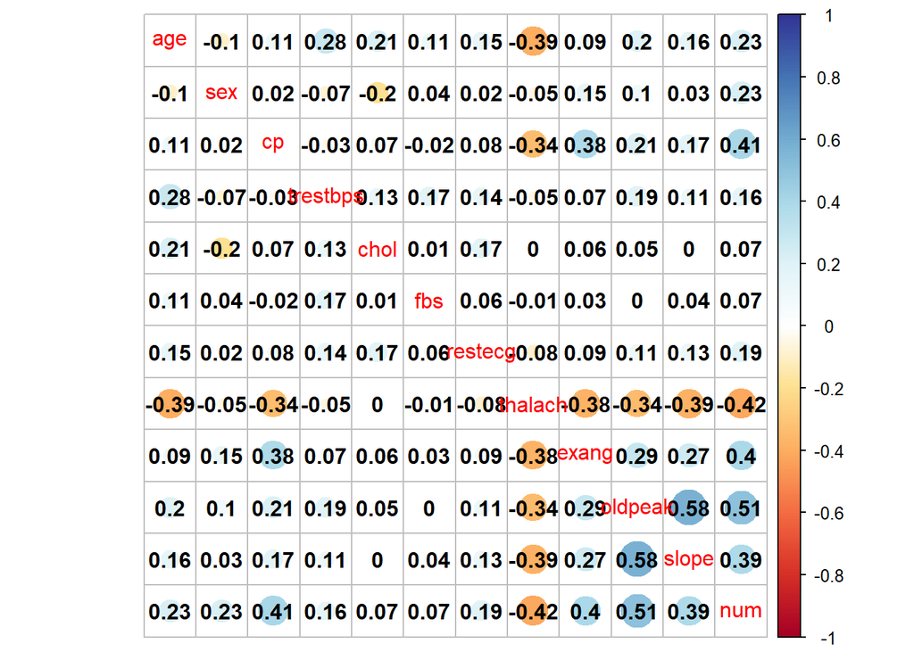

```r
#Gráfico de correlaciones
title <- "Correlaciones entre las variables de HDD"
#Matriz de correlaciones
M <- cor(data_num)
corrplot(M, col = COL2('RdYlBu'), addCoef.col = 'black', tl.pos = 'd')
```

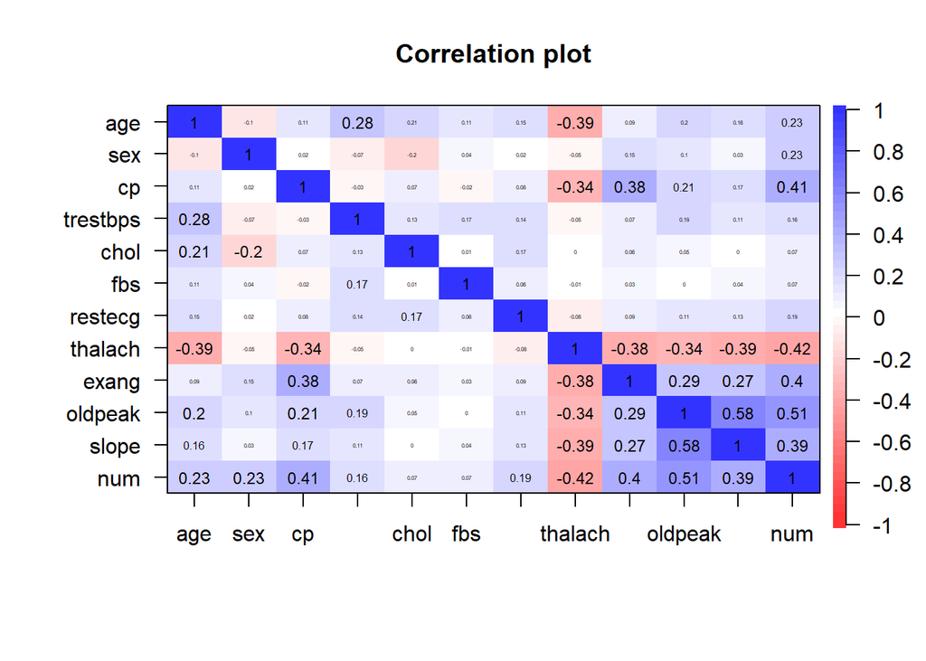

```r
corPlot(data_num, min.length = 9, cex = 0.5, alpha = 0.8, colors = TRUE )
```

Para comprender el gráfico de correlaciones, debemos tener en cuenta que si, el valor que toma es 1, quiere decir que las variables están completamente relacionadas, además el color azul más fuerte significa lo mismo, en tonalidades más claras tenemos una relación menor. Por otro lado, diremos que dos variables no están relacionadas cuando toman valores de -1, también el color rojo representa que no hay relación entre estas variables, donde el rojo más claro como rosa determina un leve incremento de la relación. El color blanco, cuyo valor asociado es el cero, indica que hay un 50% de relación entre las variables. Algunas inferencias del gráfico anterior son:

1. Las variables que están 100% relacionadas son cada una con ella misma.

2. Las variables más relacionadas son: slope con oldpeak (0.58), num con oldpeak(0.51), num con cp (0.41), num con slope (0.39), exang con cop (0.38).

3. Las variables menos relacionadas son: thalac con num (-42), thalac con age (-0.39), thalac con slope (-0.39), thalac con exang (-0.38), thalach con oldpeak (-0.34), thalac con oldpeak (-0.34).

Como consecuencia, se elimina la variable thalac y seguimos el estudio con 11 atributos.

```r
#Seleccionamos las variables numéricas sin la variable ca, thal y thalac

data_num <- data_num[,-8] # 8 es el índice de la variable thalac
head(data_num, 4)
```

```
##   age sex cp trestbps chol fbs restecg exang oldpeak slope num
## 1  67   1  4      160  286   0       2     1     1.5     2   2
## 2  67   1  4      120  229   0       2     1     2.6     2   1
## 3  37   1  3      130  250   0       0     0     3.5     3   0
## 4  41   0  2      130  204   0       2     0     1.4     1   0
```

A continuación, analizamos la correlación entre las variables mediante las distancias, mediante la métrica del máximum. Para su visualización utilizamos un mapa de calor con 15 instancias. Sólo visualizamos las primeras 2 filas

```r
# Matriz de distancias
distancias <- as.matrix(dist(data_num, method = 'maximum'))
head(distancias,2)
```

```
##    1  2  3  4  5  6   7  8  9 10 11 12 13 14  15 16 17 18 19 20 21 22 23 24 25
## 1  0 57 36 82 50 20  68 32 83 94 20 30 40 87 118 57 47 30 30 75 10 40 62 80 67
## 2 57  0 30 26 11 39 125 25 26 37 65 27 34 52  61 19 20 46 37 18 54 55 12 23 17
##    26 27 28  29 30 31  32 33 34 35  36 37  38 39 40 41 42 43  44 45  46 47  48
## 1  54 60 39 119 47 56  49 52 53 60 109 10  67 43 61 87 16 74  44 56 111 43 131
## 2 111 30 30  62 20  7 106 15 23 25  52 47 124 30 30 30 73 30 101  9  54 30 188
##   49 50  51 52 53 54 55 56  57 58 59 60  61 62 63 64 65  66 67 68 69 70 71 72
## 1 89 88 109 48 67 33 36 53 114 35 73 30 109 70 25 98 15 101 54 40 55 17 35 40
## 2 32 31  52 61 23 24 37 20  57 44 16 76  52 13 75 41 53  44 30 97 30 40 25 38
##   73 74  75 76 77 78 79 80 81 82 83 84 85 86 87 88 89 90  91 92  93 94 95 96 97
## 1 50 89  74 35 22 41 16 78 30 35 20 40 51 29 70 52 30 40 122 55 145 34 32 50 28
## 2 19 32 131 29 79 19 41 22 35 92 60 96 23 28 14 18 27 73  65 10  88 23 26 10 30
##   98 99 100 101 102 103 104 105 106 107 108 109 110 111 112 113 114 115 116 117
## 1 85 64  45 104  32  50  98  52 109  57  40  67  21  37 100  55  30  83  75 103
## 2 28 19  31  47  74  36  41  80  52  10  31  28  78  20  43 112  34  26  20  46
```

[output cut: 30 more lines]

Pero no se interpretan muy bien estos valores, para ello, realizamos un mapa de calor para 15 instancias con la métrica de pearson.

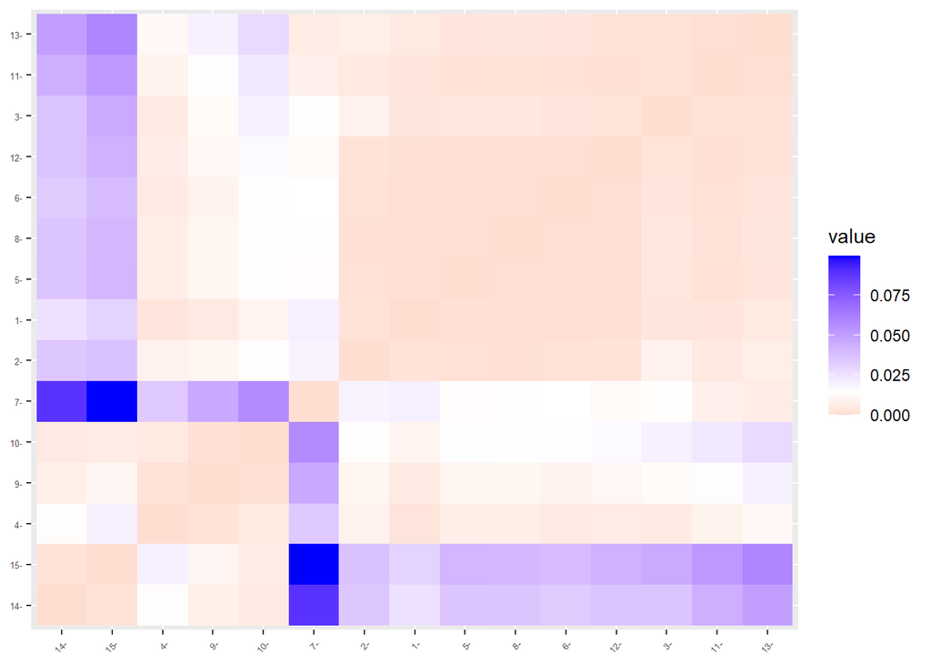

```r
# Correlación basada en el método de la distancia
res.dist <- get_dist(data_num[1:15,], method = "pearson")

# Visualize the dissimilarity matrix
fviz_dist(res.dist, lab_size = 5)
```

```r
#Escalamos el conjunto de datos sin las variables: ca, thal, thalach, num.
#tem <- data_num[,-12]
#tem <- data_num[,-8]
data_scale <- scale(data_num[,-11]) # 11 es el índice de la variable objetivo num
head(data_scale,3)
```

```
##            age       sex         cp    trestbps        chol        fbs
## [1,]  1.392608 0.6867343  0.8750283  1.60992387  0.75711513 -0.4122838
## [2,]  1.392608 0.6867343  0.8750283 -0.66122880 -0.34206509 -0.4122838
## [3,] -1.925916 0.6867343 -0.1736167 -0.09344064  0.06289604 -0.4122838
##         restecg      exang   oldpeak     slope
## [1,]  1.0184230  1.4295857 0.4002414 0.6601533
## [2,]  1.0184230  1.4295857 1.3479263 0.6601533
## [3,] -0.9917976 -0.6971871 2.1233048 2.2943034
```

```r
#Vector con datos escalados
vector1 <- data_scale

#Vector de la variable objetivo
vector2 <- data$num

# Combinamos los dos vectores usando cbind()
data1 <- cbind(vector1,vector2)
```

```r
head(data1, 2)
```

```
##           age       sex        cp   trestbps       chol        fbs  restecg
## [1,] 1.392608 0.6867343 0.8750283  1.6099239  0.7571151 -0.4122838 1.018423
## [2,] 1.392608 0.6867343 0.8750283 -0.6612288 -0.3420651 -0.4122838 1.018423
##         exang   oldpeak     slope vector2
## [1,] 1.429586 0.4002414 0.6601533       2
## [2,] 1.429586 1.3479263 0.6601533       1
```

```r
# Aplicamos los nombres a las columnas
colnames(data1) <- c('age', 'sex', 'cp', 'trestbps', 'chol', 'fbs',
                    'restecg', 'exang','oldpeak', 'slope','diagnosis')

#Lo convertimos en un dataframe
data1 <- as.data.frame(data1)
head(data1, 3)
```

```
##         age       sex         cp    trestbps        chol        fbs    restecg
## 1  1.392608 0.6867343  0.8750283  1.60992387  0.75711513 -0.4122838  1.0184230
## 2  1.392608 0.6867343  0.8750283 -0.66122880 -0.34206509 -0.4122838  1.0184230
## 3 -1.925916 0.6867343 -0.1736167 -0.09344064  0.06289604 -0.4122838 -0.9917976
##        exang   oldpeak     slope diagnosis
## 1  1.4295857 0.4002414 0.6601533         2
## 2  1.4295857 1.3479263 0.6601533         1
## 3 -0.6971871 2.1233048 2.2943034         0
```

Si analizamos los valores del atributo ‘diagnosis’, podemos ver que toma un valor de 2, pero de acuerdo a la información del conjunto de datos, esta variable sólo puede tomar valores de 0 y 1. Veamos qué valores numéricos tiene este atributo

```r
freq <- as.data.frame(table(data1$diagnosis))
freq
```

```
##   Var1 Freq
## 1    0  163
## 2    1   55
## 3    2   36
## 4    3   35
## 5    4   13
```

Basado en la tabla anterior, la variable ‘diagnosis’ toma valores de 0,1,2,3 y 4. En consecuencia, vamos a remover los datos con valores de 2,3 y 4. Ahora bien, una vez terminado esto, vamos a clasificar los datos de 0 como ‘healthy’ y de 1 como ‘heartDisease’.

```r
data1 <- data1[(data1$diagnosis=="0" | data1$diagnosis=="1"),]
head(data1)
```

```
##          age        sex         cp    trestbps        chol        fbs
## 2  1.3926081  0.6867343  0.8750283 -0.66122880 -0.34206509 -0.4122838
## 3 -1.9259163  0.6867343 -0.1736167 -0.09344064  0.06289604 -0.4122838
## 4 -1.4834463 -1.4513456 -1.2222618 -0.09344064 -0.82416167 -0.4122838
## 5  0.1758159  0.6867343 -1.2222618 -0.66122880 -0.20707804 -0.4122838
## 7  0.2864333 -1.4513456  0.8750283 -0.66122880  2.06841784 -0.4122838
## 9 -0.1560366  0.6867343  0.8750283  0.47434753 -0.84344553  2.4174822
##      restecg      exang    oldpeak      slope diagnosis
## 2  1.0184230  1.4295857  1.3479263  0.6601533         1
## 3 -0.9917976 -0.6971871  2.1233048  2.2943034         0
## 4  1.0184230 -0.6971871  0.3140882 -0.9739967         0
## 5 -0.9917976 -0.6971871 -0.2028308 -0.9739967         0
## 7 -0.9917976  1.4295857 -0.3751372 -0.9739967         0
## 9  1.0184230  1.4295857  1.7786922  2.2943034         1
```

Podemos ver que la variable diagnosis toma valores de 0 y 1 como esperábamos. Ahora la dimensión del conjunto de datos es 218 instancias y 11 columnas.

```r
dim(data1)
```

```
## [1] 218  11
```

```r
# Reasignamos los diagnósticos como healty y heartDisease
data1$diagnosis[data1$diagnosis == 0] <- "healthy"
data1$diagnosis[data1$diagnosis == 1] <- "heartDisease"

#Visualizamos los datos de las 3 primeras columnas
head(data1,3)
```

```
##         age        sex         cp    trestbps        chol        fbs    restecg
## 2  1.392608  0.6867343  0.8750283 -0.66122880 -0.34206509 -0.4122838  1.0184230
## 3 -1.925916  0.6867343 -0.1736167 -0.09344064  0.06289604 -0.4122838 -0.9917976
## 4 -1.483446 -1.4513456 -1.2222618 -0.09344064 -0.82416167 -0.4122838  1.0184230
##        exang   oldpeak      slope    diagnosis
## 2  1.4295857 1.3479263  0.6601533 heartDisease
## 3 -0.6971871 2.1233048  2.2943034      healthy
## 4 -0.6971871 0.3140882 -0.9739967      healthy
```

A partir de ahora nuestros datos están estandarizados.

```r
data2 <- as.data.frame(data1)

#Activamos las variables del dataset para llamarlas sin recurrir al conjunto de datos "data2"
attach(data2)
head(data2)
```

```
##          age        sex         cp    trestbps        chol        fbs
## 2  1.3926081  0.6867343  0.8750283 -0.66122880 -0.34206509 -0.4122838
## 3 -1.9259163  0.6867343 -0.1736167 -0.09344064  0.06289604 -0.4122838
## 4 -1.4834463 -1.4513456 -1.2222618 -0.09344064 -0.82416167 -0.4122838
## 5  0.1758159  0.6867343 -1.2222618 -0.66122880 -0.20707804 -0.4122838
## 7  0.2864333 -1.4513456  0.8750283 -0.66122880  2.06841784 -0.4122838
## 9 -0.1560366  0.6867343  0.8750283  0.47434753 -0.84344553  2.4174822
##      restecg      exang    oldpeak      slope    diagnosis
## 2  1.0184230  1.4295857  1.3479263  0.6601533 heartDisease
## 3 -0.9917976 -0.6971871  2.1233048  2.2943034      healthy
## 4  1.0184230 -0.6971871  0.3140882 -0.9739967      healthy
## 5 -0.9917976 -0.6971871 -0.2028308 -0.9739967      healthy
## 7 -0.9917976  1.4295857 -0.3751372 -0.9739967      healthy
## 9  1.0184230  1.4295857  1.7786922  2.2943034 heartDisease
```

También podemos visualizar mediante un gráfico de pares (pair-plot), las relaciones de los datos escalados de acuerdo a su diagnóstico

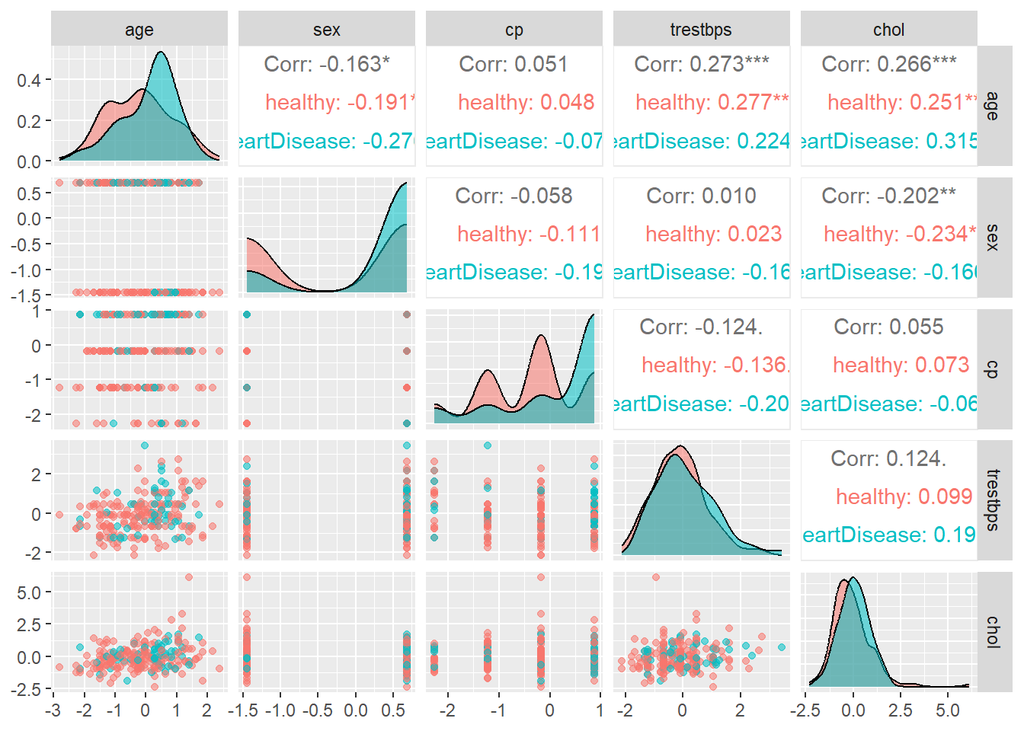

```r
# Pair-plot de las características
ggpairs(data2[,1:5], aes(colour=factor(data2$diagnosis), alpha=0.2))
```

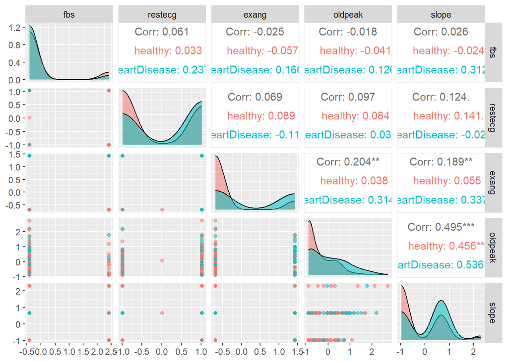

```r
# Pair-plot de las características
ggpairs(data2[,6:10], aes(colour=factor(data2$diagnosis), alpha=0.2))
```

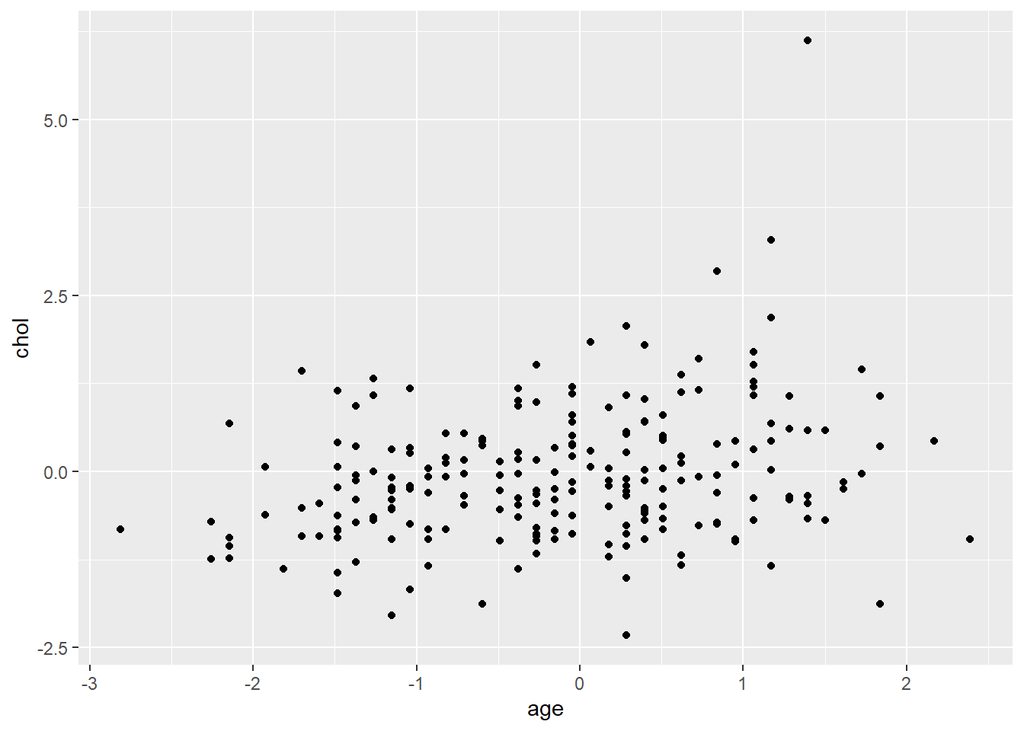

```r
ggplot(data2,
       aes(x = age,
           y=chol)) +
geom_point()
```

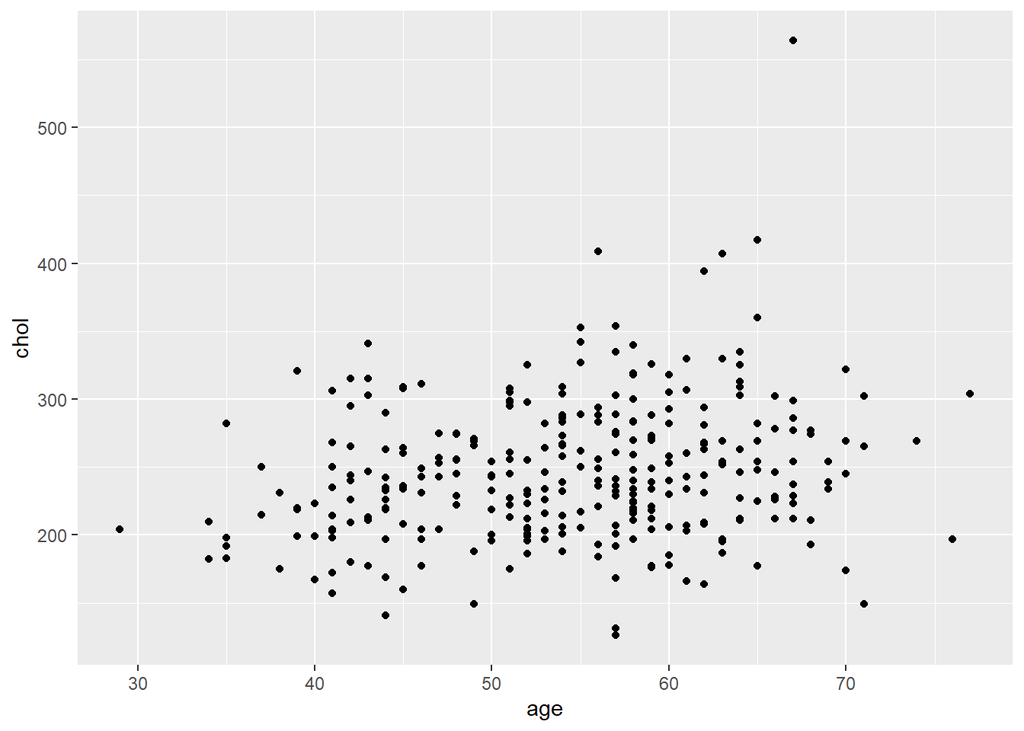

```r
ggplot(data_num,
       aes(x = age,
           y=chol)) +
geom_point()
```

Por otro lado, en general las personas con problemas del corazón tienen una edad más avanzada.

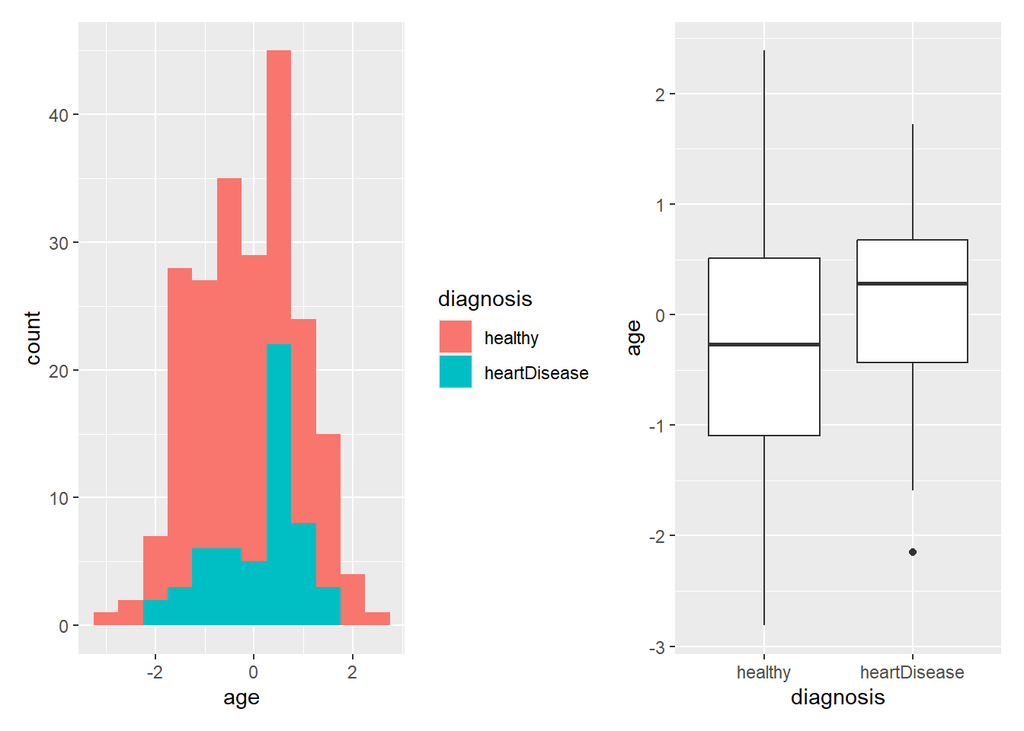

```r
p0 <- ggplot(data2, aes(x = age, fill = diagnosis)) +
geom_histogram(binwidth = .5)
p1 <- ggplot(data2, aes(diagnosis, age)) + geom_boxplot()
p0 + p1
```

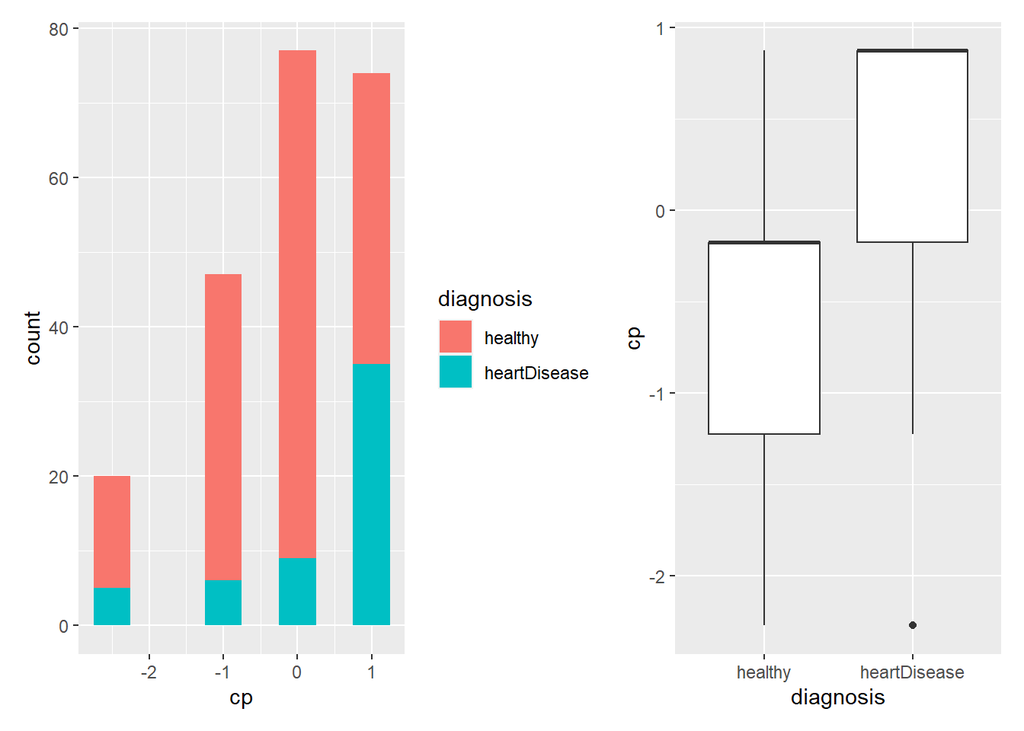

```r
p2 <- ggplot(data2, aes(x = cp, fill = diagnosis)) +
geom_histogram(binwidth = .5)
p3 <- ggplot(data2, aes(diagnosis, cp)) + geom_boxplot()
p2 + p3
```

## Modelado usando submuestras

Definimos la submuestra del conjunto de datos. Examinaremos la capacidad predictiva de un modelo, para ello, vamos a utilizar un 70% de los objetos para entrenar y un 30% para evaluar dicho modelo.

```r
n <- dim(data2)[1]
set.seed(12)
indices_aprendizaje <- sample(n, round(.7*n))
data_aprendizaje <- data2[indices_aprendizaje, ]
head(data_aprendizaje)
```

```
##            age        sex         cp    trestbps       chol        fbs
## 263 -1.1515939  0.6867343 -0.1736167 -0.66122880 -0.3999167 -0.4122838
## 125 -1.0409764 -1.4513456 -1.2222618 -0.09344064 -0.2456458 -0.4122838
## 105 -0.0454191  0.6867343 -1.2222618 -1.34257460  1.2006440 -0.4122838
## 128 -1.1515939  0.6867343 -1.2222618 -0.66122880 -0.5156199 -0.4122838
## 238 -0.5985065 -1.4513456 -1.2222618  0.13367463  0.4678572 -0.4122838
## 270  0.7289033  0.6867343  0.8750283  0.47434753 -0.7663101 -0.4122838
##        restecg      exang    oldpeak      slope    diagnosis
## 263 -0.9917976 -0.6971871 -0.8920562 -0.9739967      healthy
## 125  1.0184230 -0.6971871 -0.3751372  0.6601533      healthy
## 105 -0.9917976 -0.6971871 -0.8920562 -0.9739967      healthy
## 128 -0.9917976 -0.6971871 -0.8920562 -0.9739967      healthy
## 238 -0.9917976 -0.6971871 -0.8920562  0.6601533      healthy
## 270  1.0184230  1.4295857  0.7448541 -0.9739967 heartDisease
```

Veamos el conjunto de test:

```r
data_test <- data2[-indices_aprendizaje, ]
head(data_test)
```

```
##           age        sex         cp    trestbps       chol        fbs
## 9  -0.1560366  0.6867343  0.8750283  0.47434753 -0.8434455  2.4174822
## 13 -1.1515939  0.6867343 -1.2222618 -0.66122880  0.3135863 -0.4122838
## 27  1.2819907 -1.4513456 -2.2709068  1.04213570 -0.3999167 -0.4122838
## 32  1.0607557  0.6867343 -0.1736167  0.47434753  1.7020244 -0.4122838
## 33  0.5076683  0.6867343  0.8750283  0.19045345 -0.2456458 -0.4122838
## 34 -1.1515939  0.6867343 -0.1736167 -0.09344064 -0.2649296 -0.4122838
##       restecg      exang    oldpeak      slope    diagnosis
## 9   1.0184230  1.4295857  1.7786922  2.2943034 heartDisease
## 13 -0.9917976 -0.6971871 -0.8920562 -0.9739967      healthy
## 27 -0.9917976 -0.6971871  1.3479263  2.2943034      healthy
## 32 -0.9917976 -0.6971871 -0.8920562 -0.9739967 heartDisease
## 33 -0.9917976 -0.6971871 -0.4612903  0.6601533      healthy
## 34 -0.9917976  1.4295857 -0.5474435 -0.9739967      healthy
```

Ya tenemos las submuestras, a partir de aquí vamos a entrenar un modelo y posteriormente testar. Para empezar vamos a utilizar un modelo de regresión lineal múltiple que explique la salud del corazón en función del resto de la variables.

Ajustamos el modelo usando los datos de entrenamiento.

```r
na.omit(data_aprendizaje)
```

[output not shown]

[output cut: 293 more lines]

```r
unique(data_aprendizaje$diagnosis)
```

```
## [1] "healthy"      "heartDisease"
```

```r
data_aprendizaje <- na.omit(data_aprendizaje)
data_aprendizaje$diagnosis[data_aprendizaje$diagnosis == "healthy"] <- 0
data_aprendizaje$diagnosis[data_aprendizaje$diagnosis == "heartDisease"] <- 1

modelo <- lm(diagnosis ~ ., data=data_aprendizaje)
summary(modelo)
```

```
##
## Call:
## lm(formula = diagnosis ~ ., data = data_aprendizaje)
##
## Residuals:
##     Min      1Q  Median      3Q     Max
## -0.6507 -0.2267 -0.1062  0.2813  0.8989
##
## Coefficients:
##              Estimate Std. Error t value Pr(>|t|)
## (Intercept)  0.330904   0.036586   9.045 1.02e-15 ***
## age         -0.002125   0.038060  -0.056  0.95554
## sex          0.079327   0.034242   2.317  0.02195 *
## cp           0.067070   0.034676   1.934  0.05507 .
## trestbps     0.043246   0.035211   1.228  0.22140
## chol         0.018541   0.034760   0.533  0.59460
## fbs         -0.034381   0.037385  -0.920  0.35932
## restecg      0.047029   0.033605   1.399  0.16386
## exang        0.127944   0.040449   3.163  0.00191 **
## oldpeak     -0.006124   0.053256  -0.115  0.90862
## slope        0.072070   0.043386   1.661  0.09889 .
## ---
## Signif. codes:  0 '***' 0.001 '**' 0.01 '*' 0.05 '.' 0.1 ' ' 1
##
## Residual standard error: 0.4005 on 142 degrees of freedom
## Multiple R-squared:  0.2292, Adjusted R-squared:  0.1749
## F-statistic: 4.222 on 10 and 142 DF,  p-value: 3.837e-05
```

Las variables más relevantes son: sex, cp, exang y slope. Podría considerar, realizar un modelado con estás variables, y comparar el resultado con la anterior, veamos.

```r
modelo2 <- lm(diagnosis ~ sex + cp + exang + slope + chol, data=data_aprendizaje)
summary(modelo2)
```

```
##
## Call:
## lm(formula = diagnosis ~ sex + cp + exang + slope + chol, data = data_aprendizaje)
##
## Residuals:
##     Min      1Q  Median      3Q     Max
## -0.6872 -0.2367 -0.1298  0.3054  0.9170
##
## Coefficients:
##             Estimate Std. Error t value Pr(>|t|)
## (Intercept)  0.33005    0.03467   9.521  < 2e-16 ***
## sex          0.07857    0.03285   2.392  0.01803 *
## cp           0.06712    0.03411   1.968  0.05095 .
## exang        0.12816    0.03979   3.221  0.00157 **
## slope        0.07752    0.03727   2.080  0.03924 *
## chol         0.03206    0.03357   0.955  0.34116
## ---
## Signif. codes:  0 '***' 0.001 '**' 0.01 '*' 0.05 '.' 0.1 ' ' 1
##
## Residual standard error: 0.3995 on 147 degrees of freedom
## Multiple R-squared:  0.2058, Adjusted R-squared:  0.1787
## F-statistic: 7.616 on 5 and 147 DF,  p-value: 2.171e-06
```

El r cuadrado ajustado es un poco mejor que usando todas las variables disponibles. Veamos un poco más la validación de estos modelos.

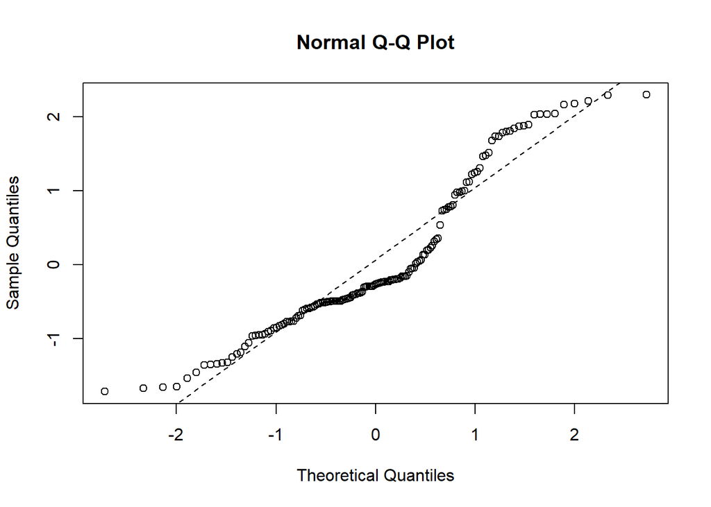

```r
# Q-Q plot
qqnorm(rstandard(modelo))
qqline(rstandard(modelo), lty = 2)
```

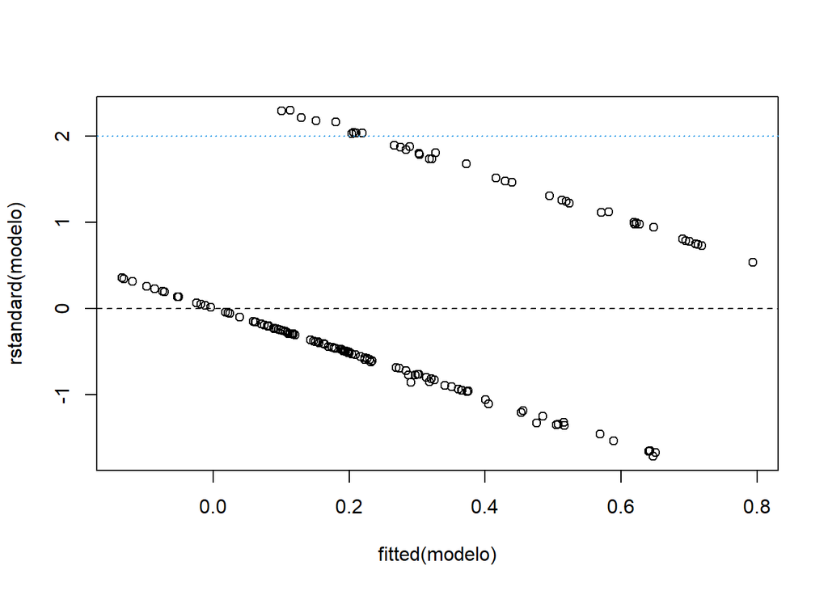

```r
# frente a valores ajustados: comprobar que la nube sea dispersa
plot(rstandard(modelo) ~ fitted(modelo))
abline(h = 0, lty = 2)
abline(h = c(-2, 2), lty = 3, col = 4)
```

```r
# Comprobar si se rechaza la normalidad de los residuos
shapiro.test(rstandard(modelo))
```

```
##
##  Shapiro-Wilk normality test
##
## data:  rstandard(modelo)
## W = 0.91525, p-value = 8.372e-08
```

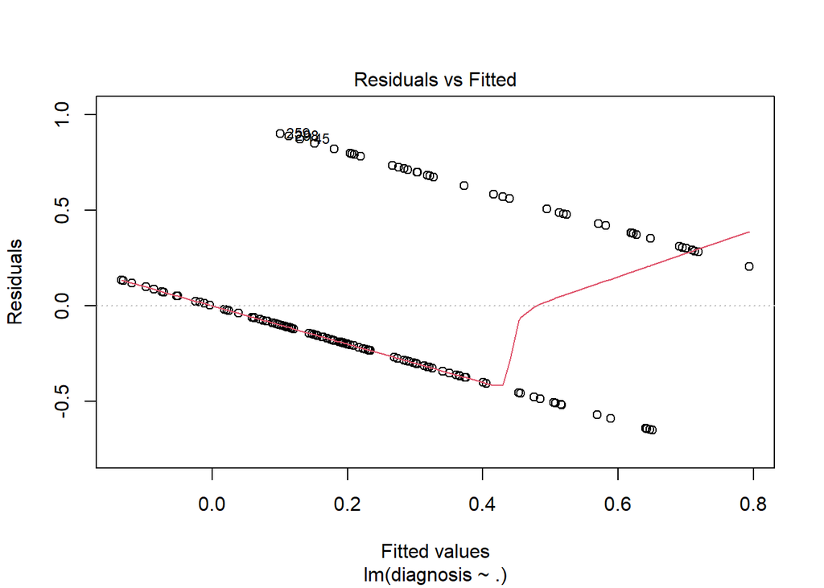

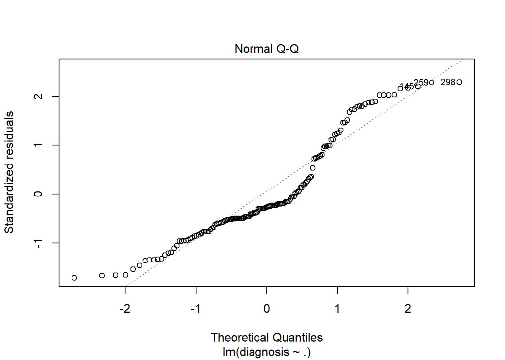

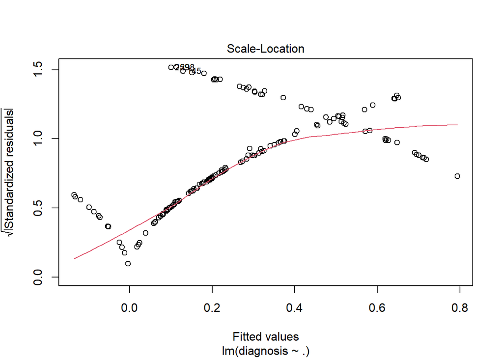

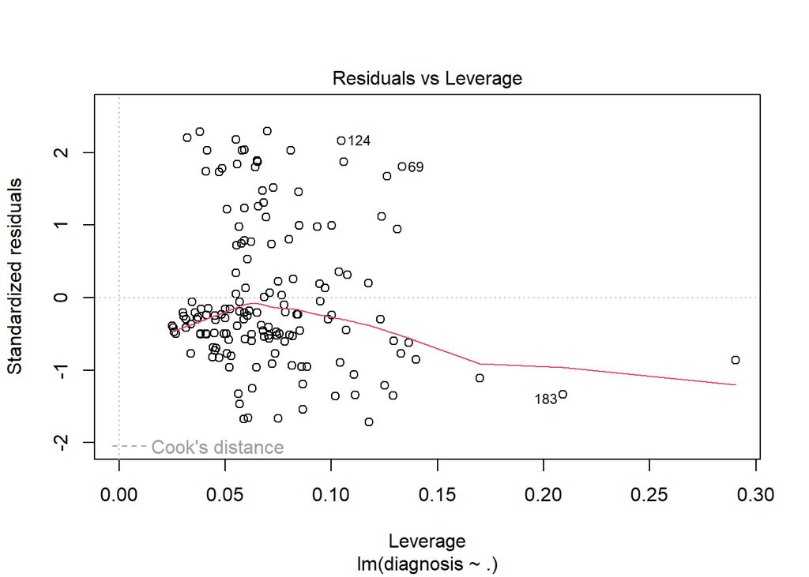

```r
# Varios gráficos de validación, incluye alguno de los resultados anteriores
plot(modelo)
```

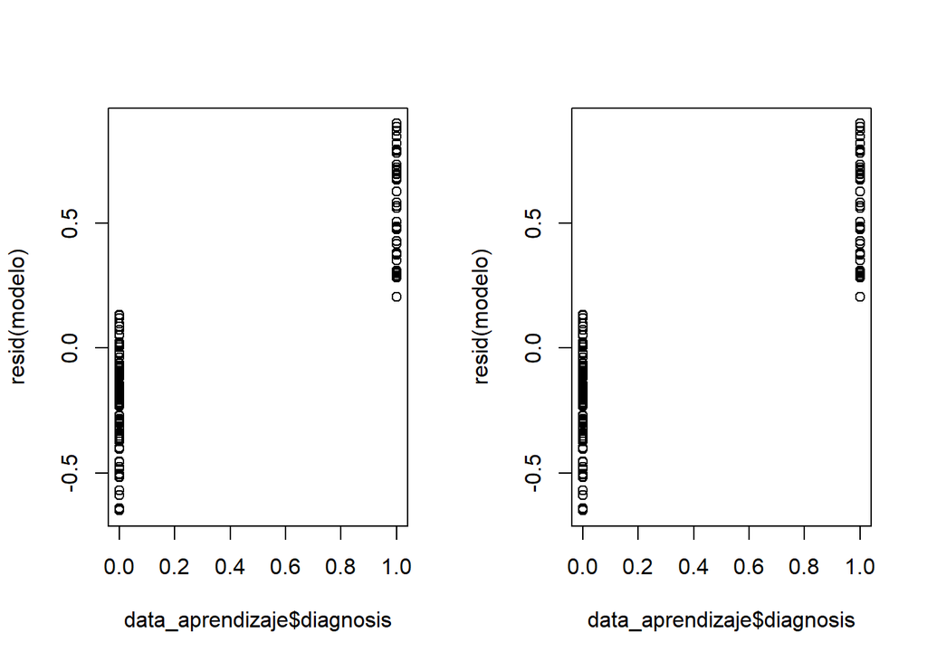

```r
# Lo realizado hasta aquí nos podría servir también para validar un modelo ANOVA,
# por ejemplo para: 'modelo <- aov(Sepal.Length ~ Species, data = iris)'
# Comprobar si son dispersas las nubes de los residuos frente a las covariables
par(mfrow = c(1, 2))
plot(resid(modelo) ~ data_aprendizaje$diagnosis)
plot(resid(modelo) ~ data_aprendizaje$diagnosis)
```

```r
par(mfrow = c(1, 1))
```

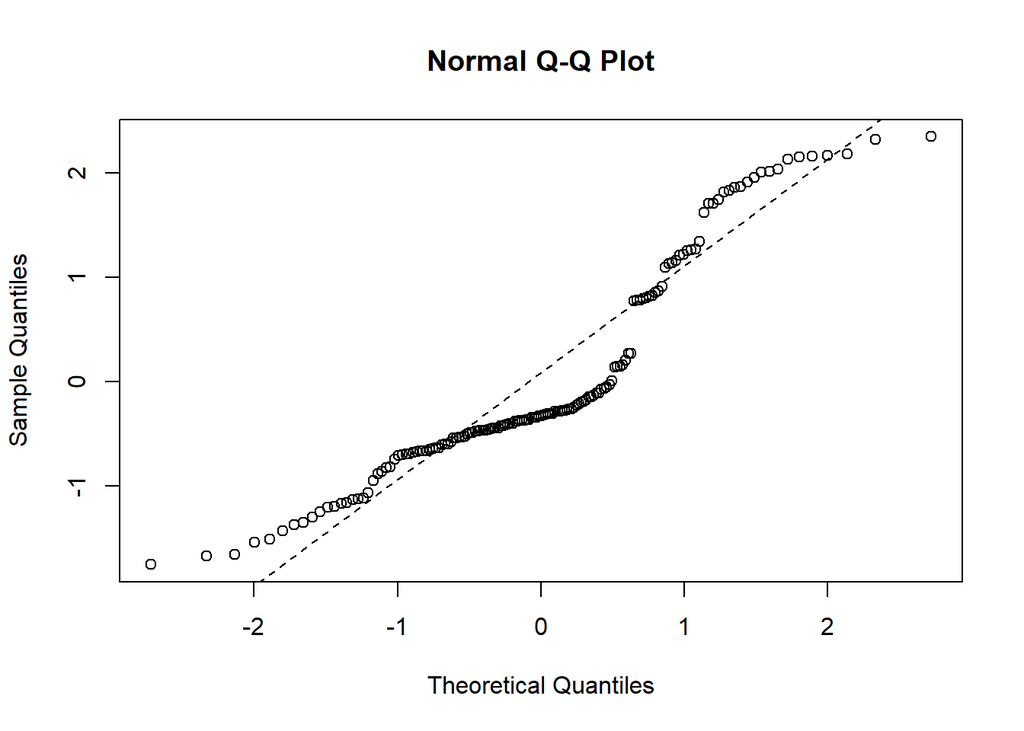

```r
qqnorm(rstandard(modelo2))
qqline(rstandard(modelo2), lty = 2)
```

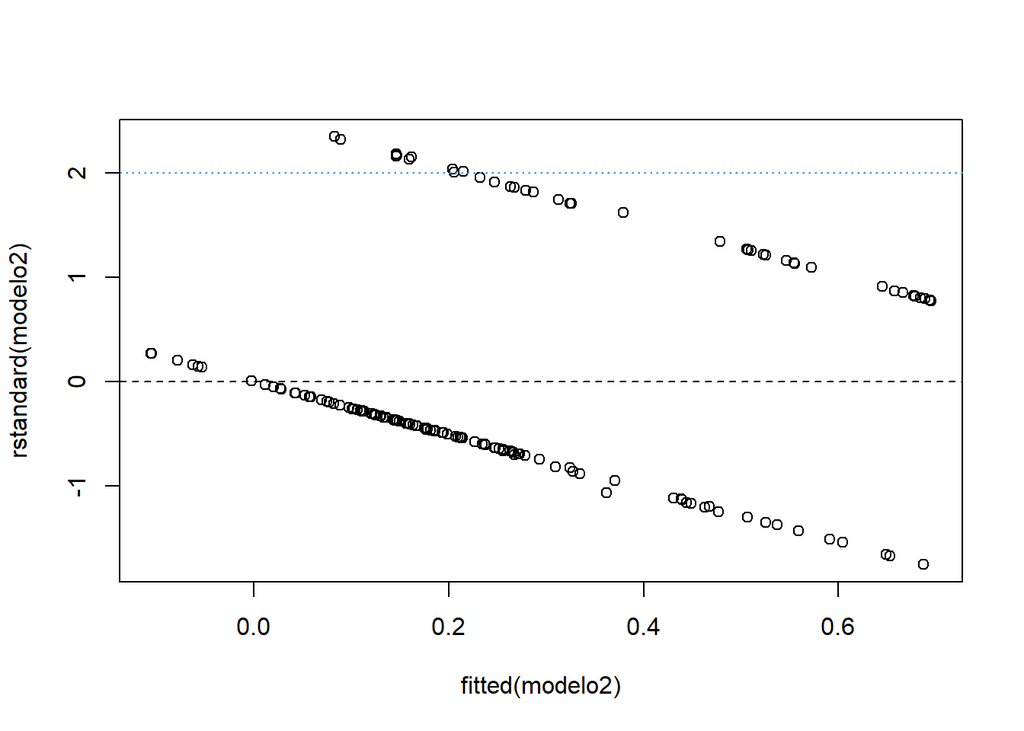

```r
plot(rstandard(modelo2) ~ fitted(modelo2))
abline(h = 0, lty = 2)
abline(h = c(-2, 2), lty = 3, col = 4)
```

```r
# Comprobar si se rechaza la normalidad de los residuos
shapiro.test(rstandard(modelo2))
```

```
##
##  Shapiro-Wilk normality test
##
## data:  rstandard(modelo2)
## W = 0.89528, p-value = 5.569e-09
```

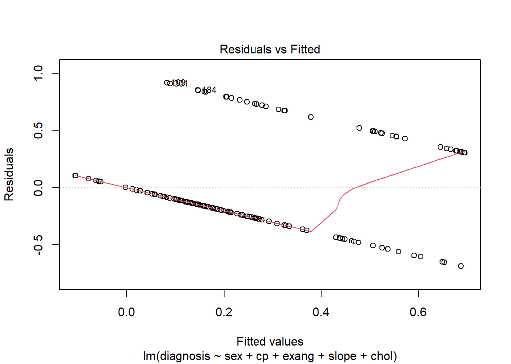

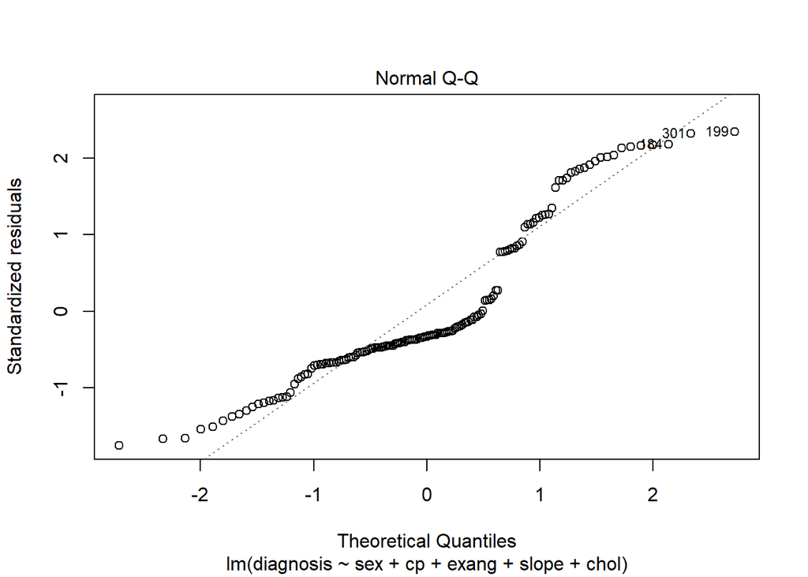

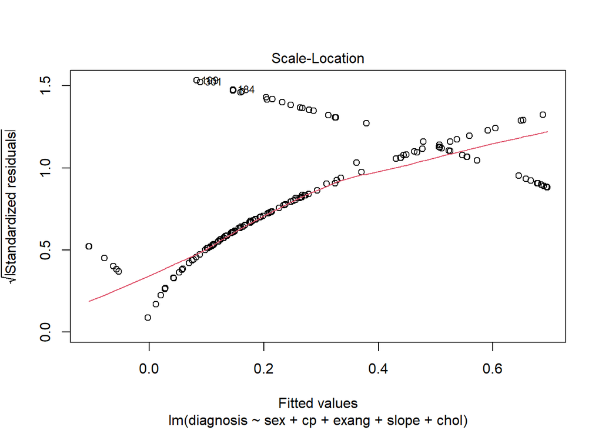

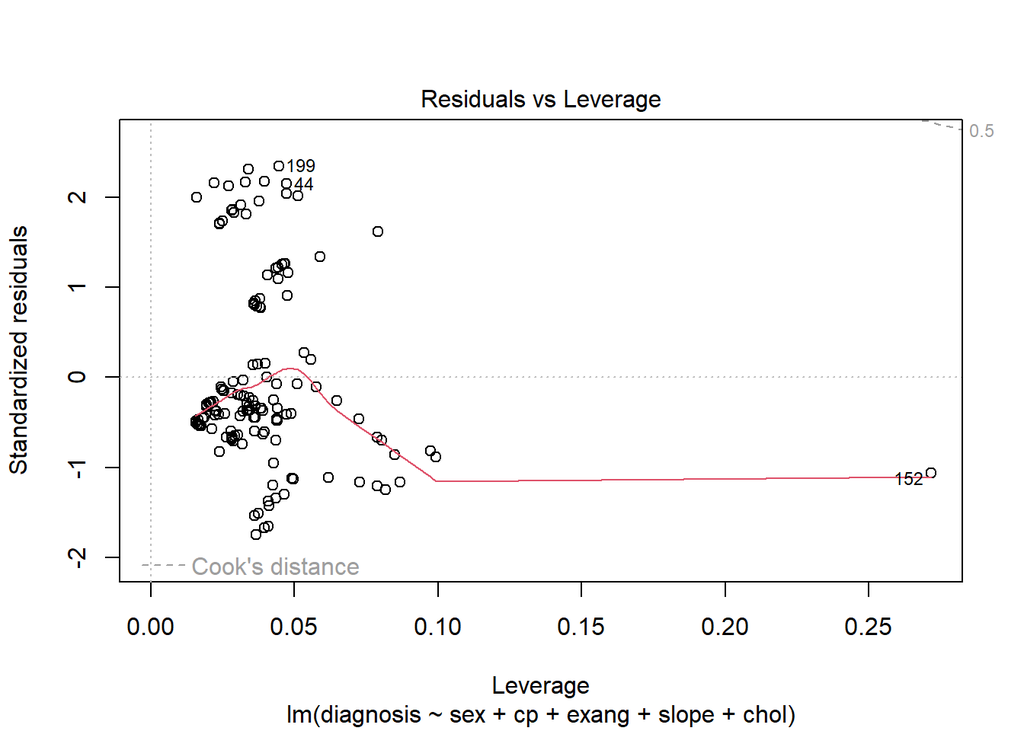

```r
# Varios gráficos de validación, incluye alguno de los resultados anteriores
plot(modelo2)
```

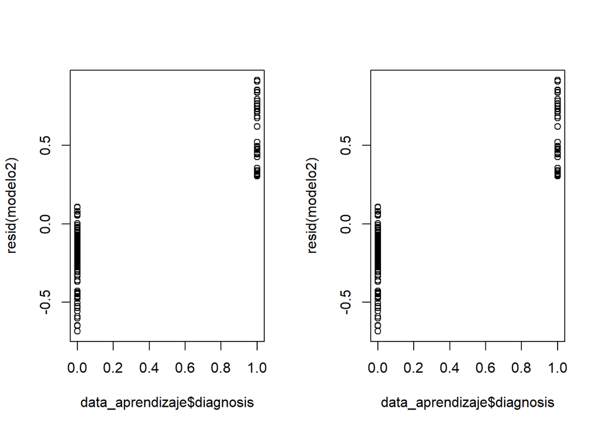

```r
# Lo realizado hasta aquí nos podría servir también para validar un modelo ANOVA,
# por ejemplo para: 'modelo <- aov(Sepal.Length ~ Species, data = iris)'
# Comprobar si son dispersas las nubes de los residuos frente a las covariables
par(mfrow = c(1, 2))
plot(resid(modelo2) ~ data_aprendizaje$diagnosis)
plot(resid(modelo2) ~ data_aprendizaje$diagnosis)
```

```r
par(mfrow = c(1, 1))
```

# Análisis de componentes principales

Tiendo en cuenta que el segundo modelo podría funcionar mejor que el primero, teniendo menos variables, vamos a realizar un análisis de las componentes principales en el dataset. Este análisis nos permite entender la varianza en función de la cantidad de variables.

```r
head(data2, 4)
```

```
##          age        sex         cp    trestbps        chol        fbs
## 2  1.3926081  0.6867343  0.8750283 -0.66122880 -0.34206509 -0.4122838
## 3 -1.9259163  0.6867343 -0.1736167 -0.09344064  0.06289604 -0.4122838
## 4 -1.4834463 -1.4513456 -1.2222618 -0.09344064 -0.82416167 -0.4122838
## 5  0.1758159  0.6867343 -1.2222618 -0.66122880 -0.20707804 -0.4122838
##      restecg      exang    oldpeak      slope    diagnosis
## 2  1.0184230  1.4295857  1.3479263  0.6601533 heartDisease
## 3 -0.9917976 -0.6971871  2.1233048  2.2943034      healthy
## 4  1.0184230 -0.6971871  0.3140882 -0.9739967      healthy
## 5 -0.9917976 -0.6971871 -0.2028308 -0.9739967      healthy
```

```r
X <- as.matrix(data2[, -11])
p <- ncol(X)
S <- cov(X)
var_tot <- sum(diag(S))
var_tot
```

```
## [1] 9.062984
```

```r
acp_cov <- prcomp(data2[,-11])
acp_cov
```

```
## Standard deviations (1, .., p=10):
##  [1] 1.2922894 1.1607314 1.1298379 0.9780670 0.9481158 0.8842278 0.8322954
##  [8] 0.7776518 0.7274873 0.5523115
##
## Rotation (n x k) = (10 x 10):
##                 PC1        PC2         PC3         PC4         PC5         PC6
## age      -0.5971503  0.1223762 -0.06656082  0.09822951 -0.36945685  0.05449890
## sex       0.2369251 -0.4852210 -0.46173620 -0.42059796 -0.19845768 -0.28022250
## cp       -0.1466008 -0.3433659  0.61960246 -0.33250880 -0.23457267  0.12230020
## trestbps -0.3224536  0.1477036 -0.37086230 -0.05319924 -0.34109014 -0.39464085
## chol     -0.4183760  0.3130329  0.14650054 -0.27916502  0.11367553 -0.14370663
## fbs      -0.0628277 -0.0164395 -0.36326901 -0.13301207 -0.25670730  0.83371122
## restecg  -0.3567639 -0.1169681 -0.21153350 -0.43834587  0.69996268  0.09868370
## exang    -0.1848044 -0.4348100  0.21572602 -0.12896949 -0.17194084 -0.04316852
## oldpeak  -0.2138337 -0.3101548 -0.09351348  0.25796261  0.02206816 -0.12711013
## slope    -0.2750747 -0.4611626 -0.08641528  0.57367744  0.23222873  0.06573817
##                  PC7         PC8         PC9         PC10
## age       0.02843524 -0.67633492  0.08160798 -0.099951956
## sex       0.33909332 -0.20786888 -0.14253946 -0.147995670
## cp       -0.19371231  0.02779644 -0.50773694 -0.007945672
## trestbps -0.46664748  0.46458641 -0.15762166 -0.057527518
## chol      0.69381370  0.32616120 -0.06252127 -0.048323647
## fbs       0.08662427  0.26424528 -0.02742178  0.084092338
## restecg  -0.31838696 -0.13890482  0.02475740  0.034358522
## exang    -0.03453002  0.23390409  0.79066621 -0.033661224
## oldpeak   0.14291084  0.02233493 -0.11905740  0.855013849
## slope     0.13059682  0.17898942 -0.21396201 -0.471132014
```

```r
summary(acp_cov)
```

```
## Importance of components:
##                           PC1    PC2    PC3    PC4     PC5     PC6     PC7
## Standard deviation     1.2923 1.1607 1.1298 0.9781 0.94812 0.88423 0.83230
## Proportion of Variance 0.1843 0.1487 0.1409 0.1056 0.09919 0.08627 0.07643
## Cumulative Proportion  0.1843 0.3329 0.4738 0.5793 0.67852 0.76479 0.84122
##                            PC8    PC9    PC10
## Standard deviation     0.77765 0.7275 0.55231
## Proportion of Variance 0.06673 0.0584 0.03366
## Cumulative Proportion  0.90795 0.9663 1.00000
```

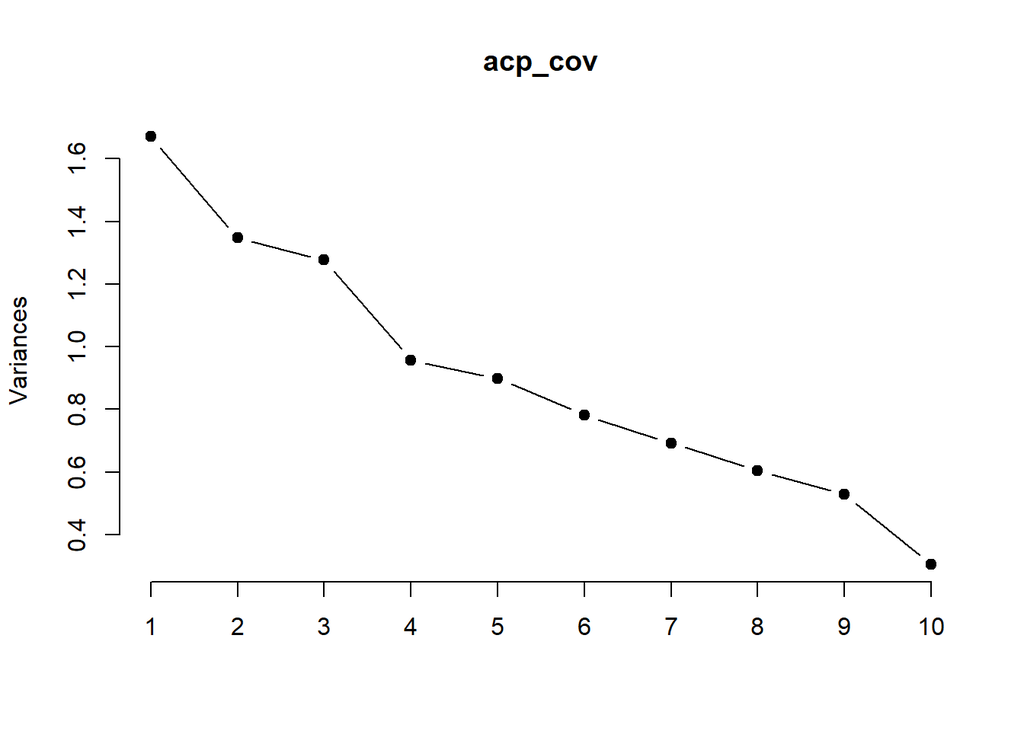

```r
plot(acp_cov, type = "l", pch = 19)
```

No es claro que hay un codo, es decir, no hay un punto donde la varianza deja de decrecer considerablemente. Veamos como se ven las primeras dos componentes.

```r
head(acp_cov$x)
```

```
##          PC1        PC2        PC3        PC4          PC5         PC6
## 2 -1.8446412 -2.5218587  0.4101156 -0.1557217 -0.008631438 -0.12981533
## 3  0.4331331 -2.1914902 -0.4172831  2.0166825  0.670978326 -0.81888758
## 4  0.7559271  0.8157130 -0.2128147  0.3329052  1.685129965  0.01708491
## 5  1.0242843  0.4860856 -0.5359432  0.2023855 -0.506886799 -0.48890218
## 7 -1.1640053  0.6579306  2.5516836 -0.5388203 -0.726217129 -0.02414817
## 9 -1.7956861 -3.6343288 -1.1908646  0.4439153 -0.218221396  1.82157113
##           PC7        PC8        PC9      PC10
## 2  0.07938283 -1.1863987  0.5182864 0.7167190
## 3  1.24185623  1.5163380 -1.5082060 0.9000921
## 4 -1.20830228  0.4384188  0.3850201 1.2854548
## 5  0.82314053 -0.9230724  0.2783585 0.2949843
## 7  1.17571472  0.7406415  1.0870897 0.2548157
## 9 -0.32232938  1.2749153 -0.2342689 0.6667828
```

```r
cov(acp_cov$x[, 1:2])
```

```
##               PC1           PC2
## PC1  1.670012e+00 -2.153619e-16
## PC2 -2.153619e-16  1.347297e+00
```

```r
# Para interpretar
acp_cov$rotation[, 1:2]
```

```
##                 PC1        PC2
## age      -0.5971503  0.1223762
## sex       0.2369251 -0.4852210
## cp       -0.1466008 -0.3433659
## trestbps -0.3224536  0.1477036
## chol     -0.4183760  0.3130329
## fbs      -0.0628277 -0.0164395
## restecg  -0.3567639 -0.1169681
## exang    -0.1848044 -0.4348100
## oldpeak  -0.2138337 -0.3101548
## slope    -0.2750747 -0.4611626
```

```r
cor(data2[, -11], acp_cov$x[, 1:2])
```

```
##                  PC1         PC2
## age      -0.75694087  0.13933086
## sex       0.29566664 -0.54387959
## cp       -0.18807825 -0.39566845
## trestbps -0.43846571  0.18039789
## chol     -0.55336407  0.37188285
## fbs      -0.08832451 -0.02075825
## restecg  -0.46045842 -0.13559660
## exang    -0.27037351 -0.57137757
## oldpeak  -0.37645840 -0.49044620
## slope    -0.37218251 -0.56044283
```

```r
diag <- cbind(data2, acp_cov$x[, 1:2])
```

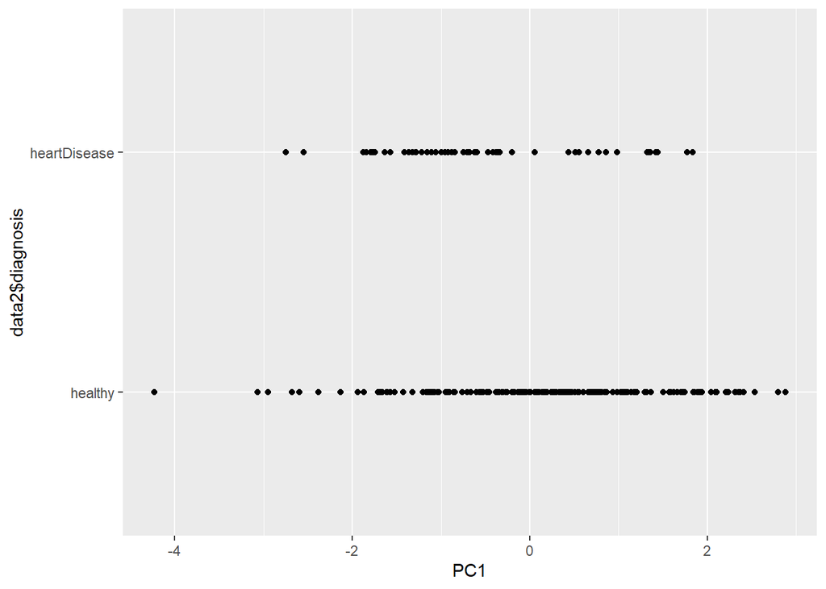

```r
ggplot(diag, aes(x = PC1, y = data2$diagnosis)) + geom_point()
```

Con una componente no es clara la utilidad de las componentes.

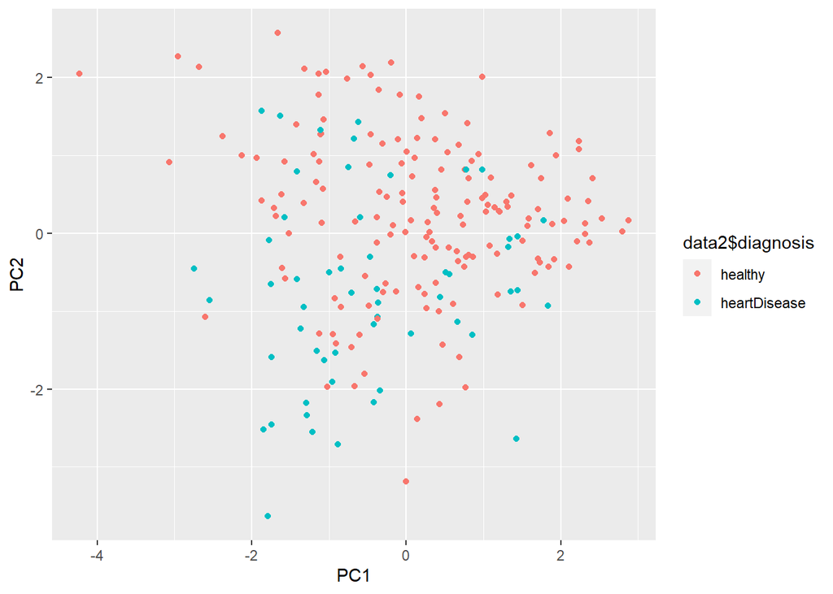

```r
ggplot(diag, aes(x = PC1, y = PC2, color = data2$diagnosis)) + geom_point()
```

Dos componentes no permiten ver claramente la diferencia entre las dos categorías. Por otro lado, el biplot nos sirve para resumir las relaciones entre variables, entre objetos y entre variables y objetos.

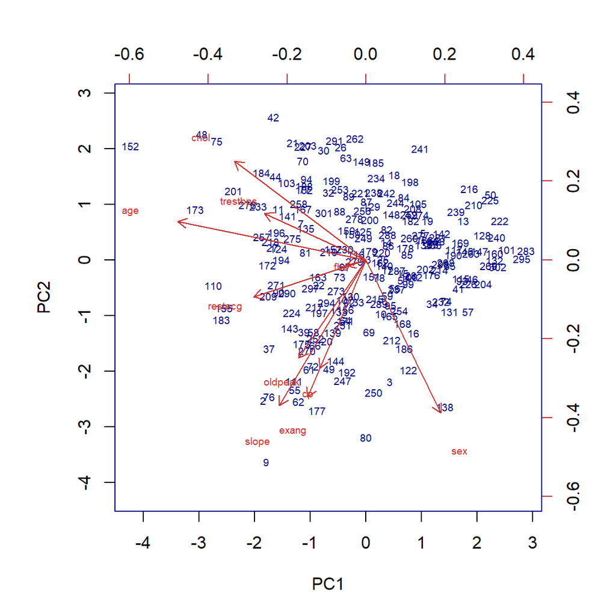

```r
biplot(acp_cov, scale = 0, cex = 0.6, col = c("blue4", "brown3"))
```

En este caso la dispersión de las variables no permite ver las diferentes contribuciones a las primeras dos componentes principales. Esto podría deberse a la poca diferencia de varianza entre las variables.

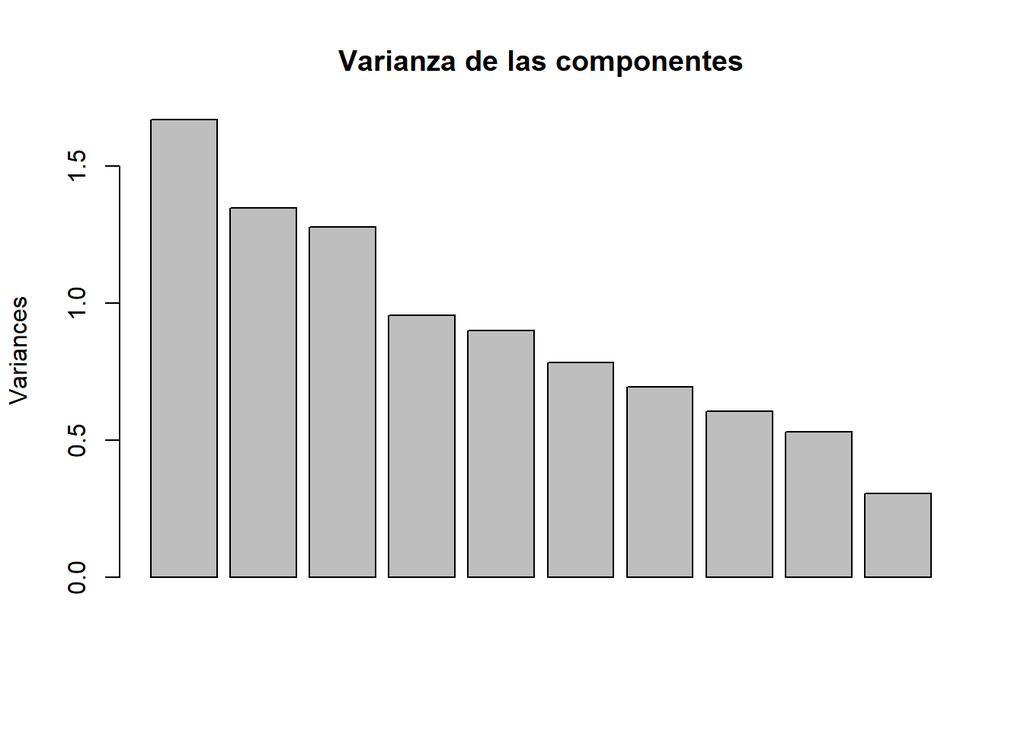

```r
plot(acp_cov, main="Varianza de las componentes")
```

Podríamos ver de manera más clara como se está acumulando la varianza en las componentes principales.

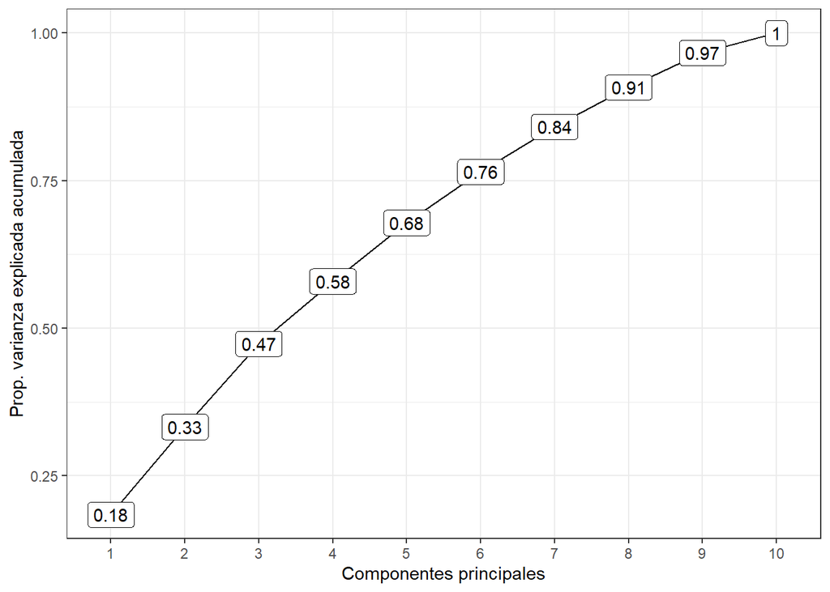

```r
prop_varianza <- acp_cov$sdev^2/sum(acp_cov$sdev^2)
prop_varianza_acum <- cumsum(prop_varianza)
ggplot(data = data.frame(prop_varianza_acum, pc = factor(1:10)),
       aes(x = pc, y = prop_varianza_acum, group = 1)) +
  geom_point() +
  geom_line() +
  geom_label(aes(label = round(prop_varianza_acum,2))) +
  theme_bw() +
  labs(x = "Componentes principales",
       y = "Prop. varianza explicada acumulada")
```

Debido a la poca acumulación de varianza en las primeras componentes, se tiene mas de un cincuenta por ciento de la varianza en las primeras cuatro componentes principales.

# Análisis factorial

El objetivo de este análisis será identificar las variables más relevantes que influyen en la presencia de enfermedades cardíacas en los pacientes. Para ello, utilizaremos técnicas de extracción de factores para encontrar patrones en las variables y reducir el número de dimensiones a unas pocas variables latentes que expliquen la mayor cantidad de variabilidad en los datos.

Una vez identificados los factores, trataremos de utilizar esta información para entender mejor la relación entre las diferentes variables y cómo influyen en la presencia de enfermedades cardíacas. Este análisis puede proporcionar información valiosa para mejorar la prevención de las enfermedades cardíacas en la población en general.

```r
X <- data2[, -11]
p <- ncol(X)
R <- cor(X)
R
```

```
##                  age          sex           cp     trestbps        chol
## age       1.00000000 -0.163432687  0.050575884  0.273128928  0.26635906
## sex      -0.16343269  1.000000000 -0.057750481  0.009796596 -0.20175523
## cp        0.05057588 -0.057750481  1.000000000 -0.123978825  0.05473986
## trestbps  0.27312893  0.009796596 -0.123978825  1.000000000  0.12422507
## chol      0.26635906 -0.201755233  0.054739856  0.124225072  1.00000000
## fbs       0.09493798  0.107216792 -0.095249101  0.089084144 -0.02442318
## restecg   0.13282122  0.028084103  0.008991095  0.112919434  0.15959783
## exang     0.08467163  0.087853366  0.321841882 -0.005984348  0.01353542
## oldpeak   0.19244721  0.124366784  0.046156375  0.103255229  0.01837994
## slope     0.12292514  0.002538958  0.032531637  0.011867156 -0.04631952
##                  fbs     restecg        exang     oldpeak        slope
## age       0.09493798 0.132821217  0.084671627  0.19244721  0.122925139
## sex       0.10721679 0.028084103  0.087853366  0.12436678  0.002538958
## cp       -0.09524910 0.008991095  0.321841882  0.04615638  0.032531637
## trestbps  0.08908414 0.112919434 -0.005984348  0.10325523  0.011867156
## chol     -0.02442318 0.159597830  0.013535421  0.01837994 -0.046319517
## fbs       1.00000000 0.060750658 -0.024755672 -0.01822332  0.026053009
## restecg   0.06075066 1.000000000  0.068873181  0.09720714  0.124386145
## exang    -0.02475567 0.068873181  1.000000000  0.20378952  0.189492983
## oldpeak  -0.01822332 0.097207141  0.203789524  1.00000000  0.494716139
## slope     0.02605301 0.124386145  0.189492983  0.49471614  1.000000000
```

```r
#Valores-vectores propios.
Rprop <- eigen(R)
Rprop
```

```
## eigen() decomposition
## $values
##  [1] 1.8720076 1.5059094 1.3396869 1.0514315 0.9237600 0.8859567 0.7295919
##  [8] 0.6346055 0.6015982 0.4554524
##
## $vectors
##              [,1]       [,2]        [,3]        [,4]        [,5]         [,6]
##  [1,] -0.41924663  0.3892483  0.04173529  0.01372482 -0.31443425  0.017344521
##  [2,]  0.01267321 -0.3701168 -0.42761127  0.41579825  0.12600819 -0.379037726
##  [3,] -0.17297998 -0.2298205  0.57590161  0.34622434 -0.13296337  0.042981972
##  [4,] -0.24599512  0.3756667 -0.29061473  0.11410029 -0.24796977 -0.561414922
##  [5,] -0.22013478  0.4729146  0.28262233  0.05112064  0.20037521  0.002057875
##  [6,] -0.05789928  0.1110591 -0.42014376  0.47449695 -0.30596770  0.656496490
##  [7,] -0.29198802  0.1596544 -0.09110947  0.27348778  0.80661532  0.111026474
##  [8,] -0.34667248 -0.3306566  0.28345580  0.37937347 -0.13904240 -0.129309010
##  [9,] -0.50990452 -0.2555867 -0.17870536 -0.30610392 -0.02855221 -0.067374594
## [10,] -0.46516975 -0.2853527 -0.14935623 -0.39224125  0.03926868  0.272793869
##               [,7]        [,8]       [,9]       [,10]
##  [1,] -0.003788003  0.47797939 -0.5694229 -0.13746629
##  [2,] -0.438817858  0.26867397 -0.0688809 -0.27941785
##  [3,]  0.114059627  0.44442106  0.4819408 -0.05842199
##  [4,]  0.352505624 -0.17383357  0.4067445 -0.06549789
##  [5,] -0.692443903 -0.25716848  0.2138981 -0.11782489
##  [6,] -0.057170380 -0.10305163  0.1733501  0.11875690
##  [7,]  0.345958091  0.09720742 -0.0629649  0.10050346
##  [8,]  0.078698306 -0.59413410 -0.3830294  0.06526196
##  [9,] -0.235040104  0.13073275  0.1431516  0.67145792
## [10,]  0.079268153 -0.12381794  0.1622768 -0.63413237
```

Porcentajes acumulados de varianza.

```r
100*cumsum(Rprop$values)/p
```

```
##  [1]  18.72008  33.77917  47.17604  57.69035  66.92795  75.78752  83.08344
##  [8]  89.42949  95.44548 100.00000
```

Al igual que en los componentes principales, para tener más de cincuenta por ciento de la varianza hay que tomar los primeros cuatro factores. Ahora, elegimos el número de factores y obtenemos la estimación de la matriz de cargas.

```r
m <- 3
sum(Rprop$values[(m + 1):p]) # cota de la suma de cuadrados de la matriz residual
```

```
## [1] 5.282396
```

```r
L <- (rep(1, p) %*% t(sqrt(Rprop$values[1:m]))) * Rprop$vectors[, 1:m]
```

```r
h2 <- rowSums(L^2)
h2
```

```
##  [1] 0.5595388 0.4515534 0.5798768 0.4389499 0.5345182 0.2613322 0.2091074
##  [8] 0.4972681 0.6278835 0.5575756
```

```r
psi <- 1 - h2
psi
```

```
##  [1] 0.4404612 0.5484466 0.4201232 0.5610501 0.4654818 0.7386678 0.7908926
##  [8] 0.5027319 0.3721165 0.4424244
```

Estimamos la matriz de correlaciones.

```r
Rbarra <- L %*%t(L) + diag(psi)
Rbarra
```

```
##              [,1]        [,2]        [,3]        [,4]        [,5]        [,6]
##  [1,]  1.00000000 -0.25080738  0.03324582  0.39702167  0.46578067  0.08704992
##  [2,] -0.25080738  1.00000000 -0.20592455 -0.04873544 -0.43071183  0.17741194
##  [3,]  0.03324582 -0.20592455  1.00000000 -0.27457331  0.12566453 -0.34384001
##  [4,]  0.39702167 -0.04873544 -0.27457331  1.00000000  0.25887621  0.25306699
##  [5,]  0.46578067 -0.43071183  0.12566453  0.25887621  1.00000000 -0.05612457
##  [6,]  0.08704992  0.17741194 -0.34384001  0.25306699 -0.05612457  1.00000000
##  [7,]  0.31765274 -0.04371915 -0.03099660  0.26025347  0.19953070  0.10963135
##  [8,]  0.09410674  0.01368898  0.44539003 -0.13777335  0.01470265 -0.17727181
##  [9,]  0.24038006  0.23273134  0.11569676  0.15979877 -0.03955413  0.11310816
## [10,]  0.18946373  0.23356997  0.13415608  0.11093243 -0.06807505  0.08676176
##              [,7]        [,8]        [,9]       [,10]
##  [1,]  0.31765274  0.09410674  0.24038006  0.18946373
##  [2,] -0.04371915  0.01368898  0.23273134  0.23356997
##  [3,] -0.03099660  0.44539003  0.11569676  0.13415608
##  [4,]  0.26025347 -0.13777335  0.15979877  0.11093243
##  [5,]  0.19953070  0.01470265 -0.03955413 -0.06807505
##  [6,]  0.10963135 -0.17727181  0.11310816  0.08676176
##  [7,]  1.00000000  0.07539624  0.23907872  0.20388774
##  [8,]  0.07539624  1.00000000  0.39031916  0.38725420
##  [9,]  0.23907872  0.39031916  1.00000000  0.58961230
## [10,]  0.20388774  0.38725420  0.58961230  1.00000000
```

Se puede observar que algunas variables están moderadamente correlacionadas, mientras que otras tienen una correlación más débil. Por ejemplo, la presión arterial (trestbps) y el colesterol (chol) tienen una correlación moderada positiva de 0.26, mientras que el sexo (sex) y y el colesterol (chol) tienen una correlación negativa moderada de -0.43. La correlación más fuerte es de 0.58, que se da entre la variable que mide la lesión al miocardio (oldpeak: Depresión del ST) y la pendiente del segmento ST (slope). Veamos la matriz residual.

```r
head(data2,3)
```

```
##         age        sex         cp    trestbps        chol        fbs    restecg
## 2  1.392608  0.6867343  0.8750283 -0.66122880 -0.34206509 -0.4122838  1.0184230
## 3 -1.925916  0.6867343 -0.1736167 -0.09344064  0.06289604 -0.4122838 -0.9917976
## 4 -1.483446 -1.4513456 -1.2222618 -0.09344064 -0.82416167 -0.4122838  1.0184230
##        exang   oldpeak      slope    diagnosis
## 2  1.4295857 1.3479263  0.6601533 heartDisease
## 3 -0.6971871 2.1233048  2.2943034      healthy
## 4 -0.6971871 0.3140882 -0.9739967      healthy
```

```r
D <- R - Rbarra
sum(D^2)
```

```
## [1] 1.287301
```

Ahora, la representación gráfica de las cargas en el espacio de los factores.

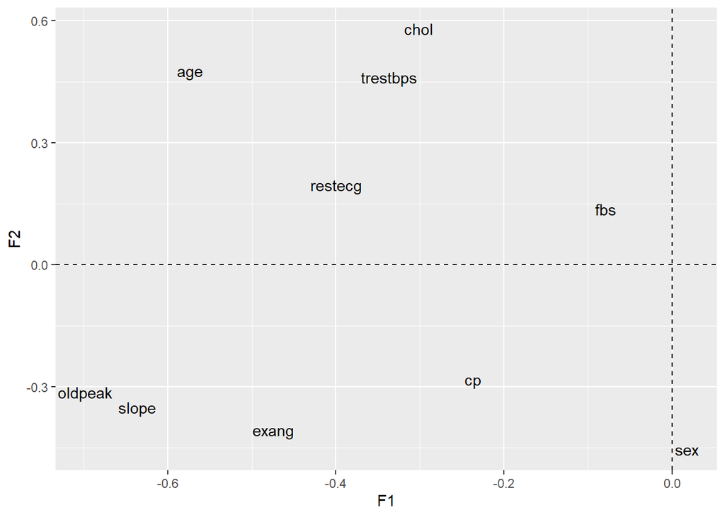

```r
L <- as.data.frame(L)
rownames(L) <- colnames(X)
colnames(L) <- c("F1", "F2")
ggplot(L, aes(x = F1, y = F2, label = rownames(L))) +
geom_hline(yintercept = 0, lty = 2) +
geom_vline(xintercept = 0, lty = 2) +
geom_text()
```

No es claro que algunas variables carguen mas en uno de los factores, con excepción la variable sexo, parece tener una carga considerable en el factor dos.

Realizamos una rotación de factores:

```r
vmax_L <- varimax(as.matrix(L))
vmax_L
```

```
## $loadings
##
## Loadings:
##          F1     F2     <NA>
## age      -0.232  0.706
## sex      -0.328 -0.501 -0.304
## cp       -0.177         0.736
## trestbps -0.134  0.462 -0.455
## chol      0.113  0.712  0.121
## fbs      -0.116        -0.497
## restecg  -0.262  0.346 -0.143
## exang    -0.518         0.478
## oldpeak  -0.788
## slope    -0.746
##
##                   F1    F2  <NA>
## SS loadings    1.752 1.603 1.362
## Proportion Var 0.175 0.160 0.136
## Cumulative Var 0.175 0.336 0.472
##
## $rotmat
##           [,1]       [,2]        [,3]
## [1,] 0.8358418 -0.5455560 -0.06113173
## [2,] 0.4938234  0.7958447 -0.35038515
## [3,] 0.2398061  0.2626783  0.93460856
```

Realizamos una representación gráfica de las cargas en el espacio de los factores rotados.

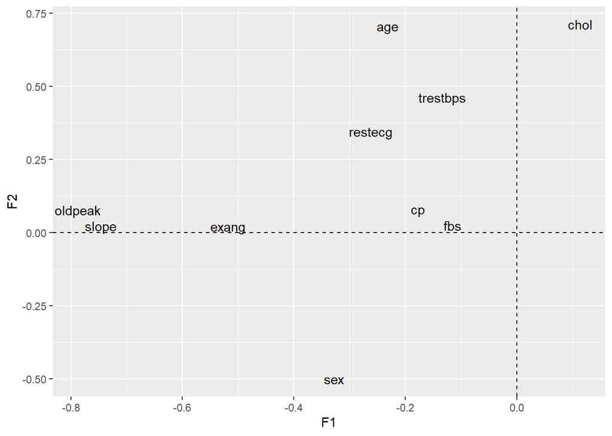

```r
Lstar <- as.data.frame(vmax_L$loadings[, 1:m])
rownames(Lstar) <- colnames(X)
colnames(Lstar) <- c("F1", "F2")
ggplot(Lstar, aes(x = F1, y = F2, label = rownames(Lstar))) +
geom_hline(yintercept = 0, lty = 2) +
geom_vline(xintercept = 0, lty = 2) +
geom_text()
```

Con los factores rotados se ve una incidencia más fuerte de la depresión del ST inducida por el ejercicio en relación con el reposo (oldpeak), angina inducida por el ejercicio (exang), pendiente del segmento ST (slope) y en menor medida, el tipo de dolor en el pecho (cp) y el azúcar en sangre en ayunas (fbs). Por otro lado veamos que, sin rotaciones funciona mejor el análisis y aumentar el número de factores no mejora de manera considerable.

```r
diagnosis_af <- principal(data2[, -(11)], nfactors = 4)
diagnosis_af
```

```
## Principal Components Analysis
## Call: principal(r = data2[, -(11)], nfactors = 4)
## Standardized loadings (pattern matrix) based upon correlation matrix
##            RC2   RC1   RC3   RC4   h2   u2 com
## age       0.71  0.18  0.04 -0.16 0.56 0.44 1.2
## sex      -0.21  0.10  0.07  0.76 0.63 0.37 1.2
## cp       -0.01 -0.06  0.82 -0.15 0.71 0.29 1.1
## trestbps  0.60  0.07 -0.23  0.18 0.45 0.55 1.5
## chol      0.61 -0.15  0.11 -0.36 0.54 0.46 1.9
## fbs       0.31 -0.12 -0.10  0.62 0.50 0.50 1.6
## restecg   0.47  0.08  0.13  0.20 0.29 0.71 1.6
## exang     0.07  0.23  0.75  0.15 0.65 0.35 1.3
## oldpeak   0.13  0.84  0.08  0.05 0.73 0.27 1.1
## slope     0.04  0.85  0.05 -0.02 0.72 0.28 1.0
##
##                        RC2  RC1  RC3  RC4
## SS loadings           1.61 1.56 1.36 1.23
## Proportion Var        0.16 0.16 0.14 0.12
## Cumulative Var        0.16 0.32 0.45 0.58
## Proportion Explained  0.28 0.27 0.24 0.21
## Cumulative Proportion 0.28 0.55 0.79 1.00
##
## Mean item complexity =  1.4
## Test of the hypothesis that 4 components are sufficient.
##
## The root mean square of the residuals (RMSR) is  0.11
##  with the empirical chi square  256.76  with prob <  1.1e-48
##
## Fit based upon off diagonal values = 0.35
```

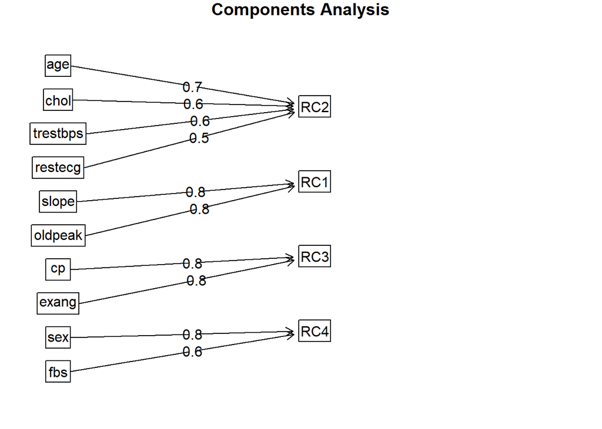

```r
fa.diagram(diagnosis_af)
```

Si tomamos cuatro componentes, en la primera aparecen la depresión del ST inducida por el ejercicio (oldpeak) y la pendiente del segmento ST (slope), que como y mencionamos estás muy correlacionadas. Pero en general no permiten ver una incidencia de ciertas variables en los factores.